# Leading Score Case Study

## Problem Statement

An online Education firm wants to find which leads are more important than the others. So that Sales and Marketing team's tasks can be organized in a way.

```python
# Importing Libraries
import numpy as np
import pandas as pd
import matplotlib.pyplot as plt
import seaborn as sns

from sklearn.model_selection import train_test_split
from sklearn.preprocessing import StandardScaler
from sklearn.feature_selection import RFECV
from sklearn.feature_selection import RFE
from sklearn.linear_model import LogisticRegression
from statsmodels.stats.outliers_influence import variance_inflation_factor

import statsmodels.api as sm

import sklearn.metrics as metrics

pd.set_option('display.max_columns', 500)
```

```python
# Reading the dataset
lead = pd.read_csv('Leads.csv')
df = lead.copy()
lead.head()
```

|  | Prospect ID | Lead Number | Lead Origin | Lead Source | Do Not Email | Do Not Call | Converted | TotalVisits | Total Time Spent on Website | Page Views Per Visit | Last Activity | Country | Specialization | How did you hear about X Education | What is your current occupation | What matters most to you in choosing a course | Search | Magazine | Newspaper Article | X Education Forums | Newspaper | Digital Advertisement | Through Recommendations | Receive More Updates About Our Courses | Tags | Lead Quality | Update me on Supply Chain Content | Get updates on DM Content | Lead Profile | … |
| --- | --- | --- | --- | --- | --- | --- | --- | --- | --- | --- | --- | --- | --- | --- | --- | --- | --- | --- | --- | --- | --- | --- | --- | --- | --- | --- | --- | --- | --- | --- |
| 0 | 7927b2df-8bba-4d29-b9a2-b6e0beafe620 | 660737 | API | Olark Chat | No | No | 0 | 0.0 | 0 | 0.0 | Page Visited on Website | NaN | Select | Select | Unemployed | Better Career Prospects | No | No | No | No | No | No | No | No | Interested in other courses | Low in Relevance | No | No | Select | … |
| 1 | 2a272436-5132-4136-86fa-dcc88c88f482 | 660728 | API | Organic Search | No | No | 0 | 5.0 | 674 | 2.5 | Email Opened | India | Select | Select | Unemployed | Better Career Prospects | No | No | No | No | No | No | No | No | Ringing | NaN | No | No | Select | … |
| 2 | 8cc8c611-a219-4f35-ad23-fdfd2656bd8a | 660727 | Landing Page Submission | Direct Traffic | No | No | 1 | 2.0 | 1532 | 2.0 | Email Opened | India | Business Administration | Select | Student | Better Career Prospects | No | No | No | No | No | No | No | No | Will revert after reading the email | Might be | No | No | Potential Lead | … |
| 3 | 0cc2df48-7cf4-4e39-9de9-19797f9b38cc | 660719 | Landing Page Submission | Direct Traffic | No | No | 0 | 1.0 | 305 | 1.0 | Unreachable | India | Media and Advertising | Word Of Mouth | Unemployed | Better Career Prospects | No | No | No | No | No | No | No | No | Ringing | Not Sure | No | No | Select | … |
| 4 | 3256f628-e534-4826-9d63-4a8b88782852 | 660681 | Landing Page Submission | Google | No | No | 1 | 2.0 | 1428 | 1.0 | Converted to Lead | India | Select | Other | Unemployed | Better Career Prospects | No | No | No | No | No | No | No | No | Will revert after reading the email | Might be | No | No | Select | … |

```python
# Shape of the DataFrame
lead.shape
```

```
(9240, 37)
```

```python
# Info
lead.info()
```

```
<class 'pandas.core.frame.DataFrame'>
RangeIndex: 9240 entries, 0 to 9239
Data columns (total 37 columns):
Prospect ID                                      9240 non-null object
Lead Number                                      9240 non-null int64
Lead Origin                                      9240 non-null object
Lead Source                                      9204 non-null object
Do Not Email                                     9240 non-null object
Do Not Call                                      9240 non-null object
Converted                                        9240 non-null int64
TotalVisits                                      9103 non-null float64
Total Time Spent on Website                      9240 non-null int64
Page Views Per Visit                             9103 non-null float64
Last Activity                                    9137 non-null object
Country                                          6779 non-null object
Specialization                                   7802 non-null object
How did you hear about X Education               7033 non-null object
What is your current occupation                  6550 non-null object
What matters most to you in choosing a course    6531 non-null object
Search                                           9240 non-null object
Magazine                                         9240 non-null object
Newspaper Article                                9240 non-null object
X Education Forums                               9240 non-null object
Newspaper                                        9240 non-null object
Digital Advertisement                            9240 non-null object
Through Recommendations                          9240 non-null object
Receive More Updates About Our Courses           9240 non-null object
Tags                                             5887 non-null object
Lead Quality                                     4473 non-null object
Update me on Supply Chain Content                9240 non-null object
Get updates on DM Content                        9240 non-null object
Lead Profile                                     6531 non-null object
City                                             7820 non-null object
Asymmetrique Activity Index                      5022 non-null object
Asymmetrique Profile Index                       5022 non-null object
Asymmetrique Activity Score                      5022 non-null float64
Asymmetrique Profile Score                       5022 non-null float64
I agree to pay the amount through cheque         9240 non-null object
A free copy of Mastering The Interview           9240 non-null object
Last Notable Activity                            9240 non-null object
dtypes: float64(4), int64(3), object(30)
memory usage: 2.6+ MB
```

```python
# Percentage of null values
(lead.isnull().sum()/len(lead))*100
```

```
Prospect ID                                       0.000000
Lead Number                                       0.000000
Lead Origin                                       0.000000
Lead Source                                       0.389610
Do Not Email                                      0.000000
Do Not Call                                       0.000000
Converted                                         0.000000
TotalVisits                                       1.482684
Total Time Spent on Website                       0.000000
Page Views Per Visit                              1.482684
Last Activity                                     1.114719
Country                                          26.634199
Specialization                                   15.562771
How did you hear about X Education               23.885281
What is your current occupation                  29.112554
What matters most to you in choosing a course    29.318182
Search                                            0.000000
Magazine                                          0.000000
Newspaper Article                                 0.000000
X Education Forums                                0.000000
Newspaper                                         0.000000
Digital Advertisement                             0.000000
Through Recommendations                           0.000000
Receive More Updates About Our Courses            0.000000
Tags                                             36.287879
Lead Quality                                     51.590909
Update me on Supply Chain Content                 0.000000
Get updates on DM Content                         0.000000
Lead Profile                                     29.318182
City                                             15.367965
Asymmetrique Activity Index                      45.649351
Asymmetrique Profile Index                       45.649351
Asymmetrique Activity Score                      45.649351
Asymmetrique Profile Score                       45.649351
I agree to pay the amount through cheque          0.000000
A free copy of Mastering The Interview            0.000000
Last Notable Activity                             0.000000
dtype: float64
```

```python
lead.describe(include = ['float','int','object'])
```

|  | Prospect ID | Lead Origin | Lead Source | Do Not Email | Do Not Call | TotalVisits | Page Views Per Visit | Last Activity | Country | Specialization | How did you hear about X Education | What is your current occupation | What matters most to you in choosing a course | Search | Magazine | Newspaper Article | X Education Forums | Newspaper | Digital Advertisement | Through Recommendations | Receive More Updates About Our Courses | Tags | Lead Quality | Update me on Supply Chain Content | Get updates on DM Content | Lead Profile | City | Asymmetrique Activity Index | Asymmetrique Profile Index | … |
| --- | --- | --- | --- | --- | --- | --- | --- | --- | --- | --- | --- | --- | --- | --- | --- | --- | --- | --- | --- | --- | --- | --- | --- | --- | --- | --- | --- | --- | --- | --- |
| count | 9240 | 9240 | 9204 | 9240 | 9240 | 9103.000000 | 9103.000000 | 9137 | 6779 | 7802 | 7033 | 6550 | 6531 | 9240 | 9240 | 9240 | 9240 | 9240 | 9240 | 9240 | 9240 | 5887 | 4473 | 9240 | 9240 | 6531 | 7820 | 5022 | 5022 | … |
| unique | 9240 | 5 | 21 | 2 | 2 | NaN | NaN | 17 | 38 | 19 | 10 | 6 | 3 | 2 | 1 | 2 | 2 | 2 | 2 | 2 | 1 | 26 | 5 | 1 | 1 | 6 | 7 | 3 | 3 | … |
| top | 52e9d0d0-4aad-46f7-a292-b0d15ec2e00d | Landing Page Submission | Google | No | No | NaN | NaN | Email Opened | India | Select | Select | Unemployed | Better Career Prospects | No | No | No | No | No | No | No | No | Will revert after reading the email | Might be | No | No | Select | Mumbai | 02.Medium | 02.Medium | … |
| freq | 1 | 4886 | 2868 | 8506 | 9238 | NaN | NaN | 3437 | 6492 | 1942 | 5043 | 5600 | 6528 | 9226 | 9240 | 9238 | 9239 | 9239 | 9236 | 9233 | 9240 | 2072 | 1560 | 9240 | 9240 | 4146 | 3222 | 3839 | 2788 | … |
| mean | NaN | NaN | NaN | NaN | NaN | 3.445238 | 2.362820 | NaN | NaN | NaN | NaN | NaN | NaN | NaN | NaN | NaN | NaN | NaN | NaN | NaN | NaN | NaN | NaN | NaN | NaN | NaN | NaN | NaN | NaN | … |
| std | NaN | NaN | NaN | NaN | NaN | 4.854853 | 2.161418 | NaN | NaN | NaN | NaN | NaN | NaN | NaN | NaN | NaN | NaN | NaN | NaN | NaN | NaN | NaN | NaN | NaN | NaN | NaN | NaN | NaN | NaN | … |
| min | NaN | NaN | NaN | NaN | NaN | 0.000000 | 0.000000 | NaN | NaN | NaN | NaN | NaN | NaN | NaN | NaN | NaN | NaN | NaN | NaN | NaN | NaN | NaN | NaN | NaN | NaN | NaN | NaN | NaN | NaN | … |
| 25% | NaN | NaN | NaN | NaN | NaN | 1.000000 | 1.000000 | NaN | NaN | NaN | NaN | NaN | NaN | NaN | NaN | NaN | NaN | NaN | NaN | NaN | NaN | NaN | NaN | NaN | NaN | NaN | NaN | NaN | NaN | … |
| 50% | NaN | NaN | NaN | NaN | NaN | 3.000000 | 2.000000 | NaN | NaN | NaN | NaN | NaN | NaN | NaN | NaN | NaN | NaN | NaN | NaN | NaN | NaN | NaN | NaN | NaN | NaN | NaN | NaN | NaN | NaN | … |
| 75% | NaN | NaN | NaN | NaN | NaN | 5.000000 | 3.000000 | NaN | NaN | NaN | NaN | NaN | NaN | NaN | NaN | NaN | NaN | NaN | NaN | NaN | NaN | NaN | NaN | NaN | NaN | NaN | NaN | NaN | NaN | … |
| max | NaN | NaN | NaN | NaN | NaN | 251.000000 | 55.000000 | NaN | NaN | NaN | NaN | NaN | NaN | NaN | NaN | NaN | NaN | NaN | NaN | NaN | NaN | NaN | NaN | NaN | NaN | NaN | NaN | NaN | NaN | … |

## Univariate

```python
# Univariate plots
def univariate(df):
    cols_int = list(df.select_dtypes("int64").columns) # extracting integer columns
    #int_cols = cols_int # copy it in another list which we can alter and this will finally become our int continuous var list
    cols_cat = list(df.select_dtypes(["object","category"]).columns) # cats
    cat_cols = cols_cat  # cats
    cols_float = list(df.select_dtypes("float64").columns) # float
    #float_cols = cols_float  # float
    cont_cols = []
    cats_anomaly = [] # cats which have alot of unique values
    if len(cols_int)>0:
        for i in range(len(cols_int)):
            unique = list(df[cols_int[i]].unique())
            if len(unique)<=11:
                cat_cols.append(cols_int[i])
                # int_cols.remove(cols_int[i])
            else:
                cont_cols.append(cols_int[i])
    if len(cols_float)>0:
        for i in range(len(cols_float)):

            if len(list(df[cols_float[i]].unique()))<=11:
                cat_cols.append(cols_float[i])
                #float_cols.remove(cols_float[i])
            else:
                cont_cols.append(cols_float[i])
    if len(cols_cat)>0:
        for i in range(len(cols_cat)):
            if ((len(list(df[cols_cat[i]].unique())))>=15):
                #cat_cols.remove(cols_cat[i])
                cats_anomaly.append(cols_cat[i])
    # Finding the size of figure and matrix
    if len(cat_cols)>0:
        if len(cat_cols)%3==0:
            a = len(cat_cols)//3
        else:
            a = 1 + len(cat_cols)//3
        b = a*5
        # plotting the cat vars
        plt.figure(figsize = (15,b))
        for i in range(len(cat_cols)):
            plt.subplot(a,3,i+1)
            sns.countplot(df[cat_cols[i]].dropna())
    s1 = plt.show()
    # Finding the size of figure and matrix
    if len(cont_cols)>0:
        if len(cont_cols)%3==0:
            a = len(cont_cols)//3
        else:
            a = 1 + len(cont_cols)//3
        b = a*5
        # plotting the cont vars
        plt.figure(figsize = (15,b))
        for i in range(len(cont_cols)):
            plt.subplot(a,3,i+1)
            sns.distplot(df[cont_cols[i]].dropna())
    s2 = plt.show()

    return print(cats_anomaly), s1, s2
```

```python
lead.columns
```

```
Index(['Prospect ID', 'Lead Number', 'Lead Origin', 'Lead Source',
       'Do Not Email', 'Do Not Call', 'Converted', 'TotalVisits',
       'Total Time Spent on Website', 'Page Views Per Visit', 'Last Activity',
       'Country', 'Specialization', 'How did you hear about X Education',
       'What is your current occupation',
       'What matters most to you in choosing a course', 'Search', 'Magazine',
       'Newspaper Article', 'X Education Forums', 'Newspaper',
       'Digital Advertisement', 'Through Recommendations',
       'Receive More Updates About Our Courses', 'Tags', 'Lead Quality',
       'Update me on Supply Chain Content', 'Get updates on DM Content',
       'Lead Profile', 'City', 'Asymmetrique Activity Index',
       'Asymmetrique Profile Index', 'Asymmetrique Activity Score',
       'Asymmetrique Profile Score',
       'I agree to pay the amount through cheque',
       'A free copy of Mastering The Interview', 'Last Notable Activity'],
      dtype='object')
```

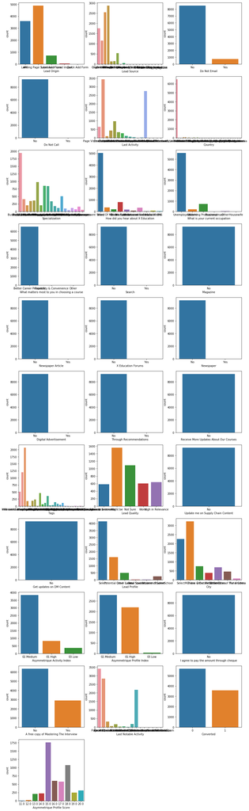

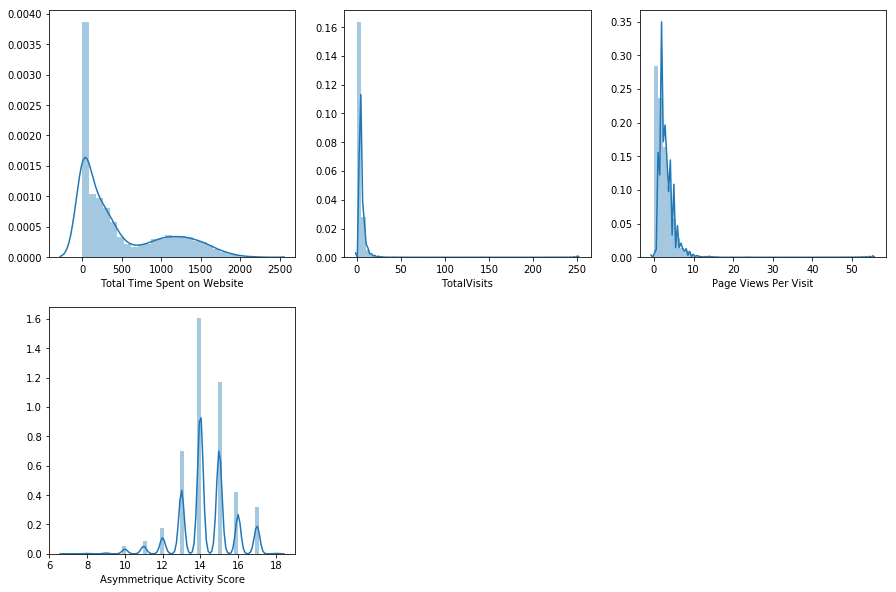

```
['Lead Source', 'Last Activity', 'Country', 'Specialization', 'Tags', 'Last Notable Activity']
```

```
(None, None, None)
```

```python
# Univariate Plots
univariate(lead.drop(columns = ['Prospect ID', 'Lead Number']))
```

- Few leads opt for not emailing them.
- A very few opt for not calling them.
- Most of the leads are from India.
- Most of the leads are unemployed.
- Few people see the ad in search bar.
- No customers see the ad in the Magazine.
- Newspaper, X Education Forums and Digital advertisement have few people who saw the ad.
- No customers want to recieve updates about X Education Courses.
- No customer wants update on supply chain content and DM Content.
- Activity and Profile Index of most customers is Medium.
- No customer wants to pay through cheque.
- Many customers want a copy of Mastering the interview.
- *Converted Column has sufficient number of customers who converted from lead to a customer.* #### Not much Imbalanced.
- Time spent on website is lesser for most customers.
- There are few customers who visted more than 200 times. Most of the cisits are less than 20.
- most of people view less than 10 pages per visit.

```python
lead.columns
```

```
Index(['Prospect ID', 'Lead Number', 'Lead Origin', 'Lead Source',
       'Do Not Email', 'Do Not Call', 'Converted', 'TotalVisits',
       'Total Time Spent on Website', 'Page Views Per Visit', 'Last Activity',
       'Country', 'Specialization', 'How did you hear about X Education',
       'What is your current occupation',
       'What matters most to you in choosing a course', 'Search', 'Magazine',
       'Newspaper Article', 'X Education Forums', 'Newspaper',
       'Digital Advertisement', 'Through Recommendations',
       'Receive More Updates About Our Courses', 'Tags', 'Lead Quality',
       'Update me on Supply Chain Content', 'Get updates on DM Content',
       'Lead Profile', 'City', 'Asymmetrique Activity Index',
       'Asymmetrique Profile Index', 'Asymmetrique Activity Score',
       'Asymmetrique Profile Score',
       'I agree to pay the amount through cheque',
       'A free copy of Mastering The Interview', 'Last Notable Activity'],
      dtype='object')
```

## Bivariate

```python
# Buvariate analysis with Target variable
def bivariate(df, target):
    cols_int = list(df.select_dtypes("int64").columns) # extracting integer columns
    #int_cols = cols_int # copy it in another list which we can alter and this will finally become our int continuous var list
    cols_cat = list(df.select_dtypes(["object","category"]).columns) # cats
    cat_cols = cols_cat  # cats
    cols_float = list(df.select_dtypes("float64").columns) # float
    #float_cols = cols_float  # float
    cont_cols = []
    cats_anomaly = [] # cats which have alot of unique values
    if len(cols_int)>0:
        for i in range(len(cols_int)):
            unique = list(df[cols_int[i]].unique())
            if len(unique)<=11:
                cat_cols.append(cols_int[i])
                # int_cols.remove(cols_int[i])
            else:
                cont_cols.append(cols_int[i])
    if len(cols_float)>0:
        for i in range(len(cols_float)):

            if len(list(df[cols_float[i]].unique()))<=11:
                cat_cols.append(cols_float[i])
                #float_cols.remove(cols_float[i])
            else:
                cont_cols.append(cols_float[i])
    if len(cols_cat)>0:
        for i in range(len(cols_cat)):
            if ((len(list(df[cols_cat[i]].unique())))>=15):
                #cat_cols.remove(cols_cat[i])
                cats_anomaly.append(cols_cat[i])
    # Finding the size of figure and matrix
    if len(cat_cols)>0:
        if len(cat_cols)%3==0:
            a = len(cat_cols)//3
        else:
            a = 1 + len(cat_cols)//3
        b = a*5
        # plotting the cat vars
        plt.figure(figsize = (15,b))
        for i in range(len(cat_cols)):
            plt.subplot(a,3,i+1)
            sns.countplot(df[cat_cols[i]].dropna(), hue = df[target])
    s1 = plt.show()
    # Finding the size of figure and matrix
    if len(cont_cols)>0:
        if len(cont_cols)%3==0:
            a = len(cont_cols)//3
        else:
            a = 1 + len(cont_cols)//3
        b = a*5
        # plotting the cont vars
        plt.figure(figsize = (15,b))
        for i in range(len(cont_cols)):
            plt.subplot(a,3,i+1)
            sns.distplot(df[df[target]==df[target].unique()[1]][cont_cols[i]].dropna(), color = 'r')
            sns.distplot(df[df[target]==df[target].unique()[0]][cont_cols[i]].dropna(), color = 'b')
    s2 = plt.show()

    return print(cats_anomaly), s1, s2
```

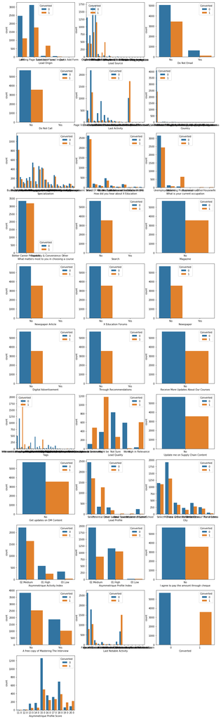

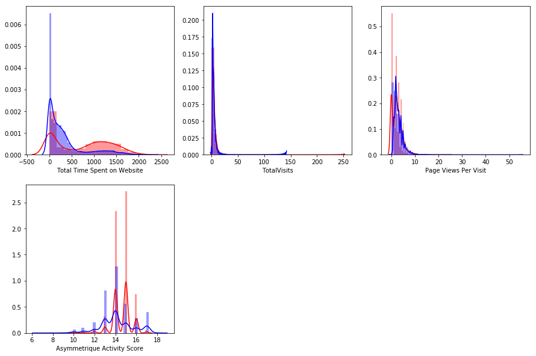

```
['Lead Source', 'Last Activity', 'Country', 'Specialization', 'Tags', 'Last Notable Activity']
```

```
(None, None, None)
```

```python
bivariate(lead.drop(columns = ['Prospect ID', 'Lead Number']), 'Converted')
```

- Customers who have high Assymtric Profile Index have high possibility of getting converted.
- Customers who spent time greater than 700units have high possibility of getting converted.

```python
lead.isnull().sum()[lead.isnull().sum()>0]/len(lead)*100
```

```
Lead Source                                       0.389610
TotalVisits                                       1.482684
Page Views Per Visit                              1.482684
Last Activity                                     1.114719
Country                                          26.634199
Specialization                                   15.562771
How did you hear about X Education               23.885281
What is your current occupation                  29.112554
What matters most to you in choosing a course    29.318182
Tags                                             36.287879
Lead Quality                                     51.590909
Lead Profile                                     29.318182
City                                             15.367965
Asymmetrique Activity Index                      45.649351
Asymmetrique Profile Index                       45.649351
Asymmetrique Activity Score                      45.649351
Asymmetrique Profile Score                       45.649351
dtype: float64
```

## Missing Value treatment

```python
lead[lead['Asymmetrique Activity Score'].isnull()]
```

|  | Prospect ID | Lead Number | Lead Origin | Lead Source | Do Not Email | Do Not Call | Converted | TotalVisits | Total Time Spent on Website | Page Views Per Visit | Last Activity | Country | Specialization | How did you hear about X Education | What is your current occupation | What matters most to you in choosing a course | Search | Magazine | Newspaper Article | X Education Forums | Newspaper | Digital Advertisement | Through Recommendations | Receive More Updates About Our Courses | Tags | Lead Quality | Update me on Supply Chain Content | Get updates on DM Content | Lead Profile | … |
| --- | --- | --- | --- | --- | --- | --- | --- | --- | --- | --- | --- | --- | --- | --- | --- | --- | --- | --- | --- | --- | --- | --- | --- | --- | --- | --- | --- | --- | --- | --- |
| 963 | 59718980-d656-4415-baeb-c223ed6abe3a | 649981 | API | Organic Search | No | No | 0 | 11.0 | 1166 | 2.20 | Page Visited on Website | India | NaN | NaN | NaN | NaN | No | No | No | No | No | No | No | No | NaN | NaN | No | No | NaN | … |
| 1363 | a8a1c41c-a21e-43bb-9120-444d79efff06 | 645610 | API | Direct Traffic | No | No | 0 | 4.0 | 446 | 1.33 | Email Opened | India | NaN | NaN | NaN | NaN | No | No | No | No | No | No | No | No | NaN | NaN | No | No | NaN | … |
| 1388 | a69a81be-f69a-45e0-9857-1f75ec740108 | 645388 | API | Google | No | No | 1 | 2.0 | 2020 | 2.00 | Email Opened | Singapore | Select | Select | Unemployed | Better Career Prospects | No | No | No | No | No | No | No | No | NaN | NaN | No | No | Select | … |
| 1401 | 4e5cae69-5632-4db3-af8f-7e1b2c9b552e | 645333 | API | Google | No | No | 1 | 3.0 | 1459 | 3.00 | Email Opened | India | Select | Select | Unemployed | Better Career Prospects | No | No | No | No | No | No | No | No | NaN | NaN | No | No | Select | … |
| 1513 | 14f31910-89a3-4f38-b803-dbb57999ae44 | 644225 | API | Google | No | No | 0 | 6.0 | 481 | 6.00 | Email Opened | India | NaN | NaN | NaN | NaN | No | No | No | No | No | No | No | No | Interested in other courses | NaN | No | No | NaN | … |
| 2320 | 58b283ba-e92a-4413-802e-ef8a93d356cc | 637281 | API | Direct Traffic | No | No | 0 | 10.0 | 225 | 2.50 | Page Visited on Website | India | NaN | NaN | NaN | NaN | No | No | No | No | No | No | No | No | Interested in other courses | NaN | No | No | NaN | … |
| 2629 | db323639-2a95-4c9a-b2df-ed5b856501cb | 634254 | Lead Add Form | Reference | No | No | 1 | 0.0 | 0 | 0.00 | Email Opened | NaN | Human Resource Management | Select | Unemployed | Better Career Prospects | No | No | No | No | No | No | No | No | Will revert after reading the email | High in Relevance | No | No | Potential Lead | … |
| 2631 | a27000ab-4a0b-4231-9ee2-a1a9e85b90ef | 634237 | Lead Add Form | Reference | Yes | No | 1 | 0.0 | 0 | 0.00 | SMS Sent | NaN | Finance Management | Select | Unemployed | Better Career Prospects | No | No | No | No | No | No | No | No | Will revert after reading the email | Might be | No | No | Potential Lead | … |
| 2632 | 4d0d7ff2-a458-4b09-80b4-a493efc9fba5 | 634228 | Lead Add Form | Reference | No | No | 1 | 0.0 | 0 | 0.00 | SMS Sent | NaN | Select | Select | Unemployed | Better Career Prospects | No | No | No | No | No | No | No | No | Will revert after reading the email | Might be | No | No | Potential Lead | … |
| 2633 | ccf1d6b3-6893-41bd-89e6-df4102f39895 | 634222 | API | Google | No | No | 0 | 2.0 | 397 | 1.00 | Email Opened | India | NaN | NaN | NaN | NaN | No | No | No | No | No | No | No | No | NaN | NaN | No | No | NaN | … |
| 2635 | 9836d58d-a4a8-4d67-9a7a-864731f4da1d | 634213 | API | Google | No | No | 0 | 3.0 | 49 | 3.00 | Converted to Lead | India | NaN | NaN | NaN | NaN | No | No | No | No | No | No | No | No | NaN | NaN | No | No | NaN | … |
| 2643 | e33719f6-4028-4d70-8fa1-5481c2e89d7f | 634102 | Lead Add Form | Reference | No | No | 1 | 0.0 | 0 | 0.00 | SMS Sent | NaN | Marketing Management | Select | Working Professional | Better Career Prospects | No | No | No | No | No | No | No | No | Will revert after reading the email | Might be | No | No | Potential Lead | … |
| 2644 | c00ed6a5-b70d-4a9d-b324-45b54017a1c1 | 634094 | API | Google | No | No | 1 | 4.0 | 659 | 4.00 | SMS Sent | India | Select | Select | Unemployed | Better Career Prospects | No | No | No | No | No | No | No | No | NaN | NaN | No | No | Select | … |
| 2646 | d4b72386-5460-4a90-a4e2-1cbaa927cbad | 634084 | API | Olark Chat | No | No | 0 | 0.0 | 0 | 0.00 | Olark Chat Conversation | NaN | Select | Select | Unemployed | Better Career Prospects | No | No | No | No | No | No | No | No | Diploma holder (Not Eligible) | NaN | No | No | Select | … |
| 2650 | 186882cb-862f-432d-a718-8fbe2b8b64c6 | 634068 | Lead Add Form | Reference | Yes | No | 1 | 0.0 | 0 | 0.00 | SMS Sent | NaN | Banking, Investment And Insurance | Select | Working Professional | Better Career Prospects | No | No | No | No | No | No | No | No | Will revert after reading the email | Might be | No | No | Potential Lead | … |
| 2651 | ede58fc6-9182-4b5c-9c31-07f22d0947e2 | 634060 | Lead Add Form | Welingak Website | No | No | 1 | 0.0 | 0 | 0.00 | Email Opened | NaN | Select | Select | Unemployed | Better Career Prospects | No | No | No | No | No | No | No | No | NaN | NaN | No | No | Select | … |
| 2652 | 9e2ed79c-5959-44ee-b7a5-0d896d730344 | 634057 | Landing Page Submission | Organic Search | No | No | 1 | 3.0 | 1394 | 3.00 | SMS Sent | India | Supply Chain Management | Select | Unemployed | Better Career Prospects | No | No | No | No | No | No | No | No | NaN | NaN | No | No | Select | … |
| 2653 | 84198fb6-a579-4f25-80c9-3ad6cf3b13dc | 634056 | Lead Add Form | Reference | No | No | 1 | 0.0 | 0 | 0.00 | Email Opened | NaN | Banking, Investment And Insurance | Select | Working Professional | Better Career Prospects | No | No | No | No | No | No | No | No | Will revert after reading the email | Might be | No | No | Potential Lead | … |
| 2654 | 01b01543-5f22-4bbe-a8c0-178cfd209926 | 634053 | API | Google | No | No | 1 | 2.0 | 1494 | 1.00 | Email Opened | India | Select | Select | Unemployed | Better Career Prospects | No | No | No | No | No | No | No | No | NaN | NaN | No | No | Select | … |
| 2655 | 3d7f214b-2eac-49af-a4a6-e23d3cf880e4 | 634051 | Lead Add Form | Reference | No | No | 1 | 0.0 | 0 | 0.00 | SMS Sent | NaN | Marketing Management | Select | Working Professional | Better Career Prospects | No | No | No | No | No | No | No | No | Will revert after reading the email | Might be | No | No | Potential Lead | … |
| 2656 | 59996c52-d485-48c6-9777-d8deaec1e4ab | 634047 | Lead Add Form | Reference | No | No | 1 | NaN | 1721 | NaN | NaN | NaN | Operations Management | Select | Working Professional | Better Career Prospects | No | No | No | No | No | No | No | No | Lost to EINS | Might be | No | No | Potential Lead | … |
| 2657 | 156474e3-446d-407f-95a2-e0fd58d740c7 | 634043 | Lead Add Form | Reference | No | No | 1 | 0.0 | 0 | 0.00 | SMS Sent | NaN | Marketing Management | Select | Working Professional | Better Career Prospects | No | No | No | No | No | No | No | No | Will revert after reading the email | Might be | No | No | Potential Lead | … |
| 2658 | 6cb07bc3-6d9d-47a4-81e1-5c50011e380e | 634040 | Lead Add Form | Reference | No | No | 1 | 0.0 | 0 | 0.00 | SMS Sent | NaN | Business Administration | Select | Working Professional | Better Career Prospects | No | No | No | No | No | No | No | No | Will revert after reading the email | Might be | No | No | Potential Lead | … |
| 2659 | 33646db8-50d2-4b90-b953-64210b3d237d | 634036 | Lead Add Form | Reference | No | No | 1 | 0.0 | 0 | 0.00 | Email Opened | NaN | Marketing Management | Select | Working Professional | Better Career Prospects | No | No | No | No | No | No | No | No | Will revert after reading the email | Might be | No | No | Potential Lead | … |
| 2661 | 419ae0f6-7c68-439a-a25c-3152d9fe8632 | 634027 | Lead Add Form | Reference | No | No | 1 | 0.0 | 0 | 0.00 | SMS Sent | NaN | Finance Management | Select | Working Professional | Better Career Prospects | No | No | No | No | No | No | No | No | Will revert after reading the email | Might be | No | No | Potential Lead | … |
| 2662 | 2c0b2139-7541-4724-89ff-7b4e76ee62a5 | 634024 | Lead Add Form | Reference | No | No | 1 | 0.0 | 0 | 0.00 | SMS Sent | NaN | Human Resource Management | Select | Working Professional | Better Career Prospects | No | No | No | No | No | No | No | No | Will revert after reading the email | Might be | No | No | Potential Lead | … |
| 2664 | 10356427-09ca-4dd5-931c-3703130d3ba4 | 634018 | Lead Add Form | Reference | No | No | 1 | 0.0 | 0 | 0.00 | SMS Sent | NaN | Human Resource Management | Select | Unemployed | Better Career Prospects | No | No | No | No | No | No | No | No | Will revert after reading the email | High in Relevance | No | No | Potential Lead | … |
| 2665 | 6317608b-82f6-4279-8964-428a56c1bebe | 634015 | Lead Add Form | Reference | No | No | 1 | 0.0 | 0 | 0.00 | SMS Sent | NaN | Marketing Management | Select | Working Professional | Better Career Prospects | No | No | No | No | No | No | No | No | Will revert after reading the email | Might be | No | No | Potential Lead | … |
| 2671 | 3cdfd474-3f10-408c-bb4f-95fdcff02895 | 633971 | API | Olark Chat | No | No | 0 | 0.0 | 0 | 0.00 | Email Link Clicked | NaN | NaN | NaN | NaN | NaN | No | No | No | No | No | No | No | No | NaN | NaN | No | No | NaN | … |
| 2672 | 37465564-9752-4a25-adb0-8beeb99b7a95 | 633965 | Lead Add Form | Reference | No | No | 1 | 0.0 | 0 | 0.00 | SMS Sent | NaN | Finance Management | Select | Working Professional | Better Career Prospects | No | No | No | No | No | No | No | No | Will revert after reading the email | Might be | No | No | Potential Lead | … |
| ... | ... | ... | ... | ... | ... | ... | ... | ... | ... | ... | ... | ... | ... | ... | ... | ... | ... | ... | ... | ... | ... | ... | ... | ... | ... | ... | ... | ... | ... | … |
| 7400 | 73fe42ea-3564-43bc-a779-f5efff588d46 | 592726 | API | Google | No | No | 0 | 6.0 | 1135 | 3.00 | Email Opened | India | NaN | NaN | NaN | NaN | No | No | No | No | No | No | No | No | NaN | NaN | No | No | NaN | … |
| 7555 | 0473623b-9d46-418e-ac65-9ebfce3a4d6b | 591682 | Landing Page Submission | Organic Search | No | No | 0 | 9.0 | 155 | 1.50 | Email Opened | India | Business Administration | Select | Unemployed | Better Career Prospects | No | No | No | No | No | No | No | No | Graduation in progress | NaN | No | No | Select | … |
| 7567 | afeab77a-8544-4c64-8a9c-3b6baa7e8802 | 591606 | Landing Page Submission | Google | No | No | 0 | 6.0 | 461 | 2.00 | Page Visited on Website | India | Business Administration | Word Of Mouth | NaN | NaN | No | No | No | No | No | No | No | No | NaN | NaN | No | No | NaN | … |
| 7649 | 831acf2b-9e5d-4061-b7dd-904e6e0e0d32 | 591116 | Landing Page Submission | Google | No | No | 0 | 3.0 | 270 | 1.50 | Email Opened | India | International Business | NaN | NaN | NaN | No | No | No | No | No | No | No | No | NaN | NaN | No | No | NaN | … |
| 7724 | 6defa594-0e9e-43c6-ae02-dbaafc664b2d | 590600 | Landing Page Submission | Organic Search | No | No | 0 | 8.0 | 61 | 4.00 | Email Opened | India | Media and Advertising | NaN | NaN | NaN | No | No | No | No | No | No | No | No | NaN | NaN | No | No | NaN | … |
| 7856 | 924ad2cb-4c83-486c-b739-7398f1fafffb | 589518 | Landing Page Submission | Direct Traffic | No | No | 1 | 8.0 | 642 | 2.00 | Email Opened | India | Business Administration | Online Search | Unemployed | Better Career Prospects | No | No | No | No | No | No | No | No | Will revert after reading the email | High in Relevance | No | No | Potential Lead | … |
| 7862 | 4ea08af9-502f-4be7-915e-c95d6a0f9313 | 589466 | Landing Page Submission | Google | No | No | 0 | 27.0 | 340 | 3.38 | Email Opened | India | Hospitality Management | Online Search | Unemployed | Better Career Prospects | No | No | No | No | No | No | No | No | Ringing | NaN | No | No | Select | … |
| 7918 | 6ceaa207-bb3a-46ac-a16b-ab386036c96d | 589049 | Landing Page Submission | Organic Search | Yes | No | 0 | 4.0 | 1377 | 2.00 | Email Bounced | India | Travel and Tourism | NaN | NaN | NaN | No | No | No | No | No | No | No | No | NaN | NaN | No | No | NaN | … |
| 7930 | d1b7ff72-89a0-40f8-9527-52e6fbaa18c9 | 588994 | Landing Page Submission | Google | No | No | 0 | 7.0 | 1602 | 1.40 | Email Opened | India | Supply Chain Management | Select | Unemployed | Better Career Prospects | No | No | No | No | No | No | No | No | Ringing | NaN | No | No | Select | … |
| 8025 | d52e7876-c50a-4f05-aeaf-082e4fdc2fe9 | 588255 | API | Direct Traffic | No | No | 1 | 9.0 | 1448 | 1.80 | Email Opened | NaN | Select | Select | Unemployed | Better Career Prospects | No | No | No | No | No | No | No | No | Already a student | NaN | No | No | Select | … |
| 8129 | d644fbbf-c033-4034-8fa5-74f62a71209f | 587777 | Landing Page Submission | Direct Traffic | No | No | 0 | 7.0 | 961 | 1.75 | SMS Sent | India | Finance Management | Select | Unemployed | Better Career Prospects | No | No | No | No | No | No | No | No | Ringing | Might be | No | No | Select | … |
| 8203 | 61da919a-0a23-42b4-97a7-ad66695c68ae | 587277 | API | Direct Traffic | Yes | No | 0 | 25.0 | 269 | 1.19 | Page Visited on Website | India | NaN | NaN | NaN | NaN | No | No | No | No | No | No | No | No | NaN | NaN | No | No | NaN | … |
| 8216 | e136fc28-c1a4-47d4-9940-167f80db2c20 | 587204 | API | Google | No | No | 0 | 7.0 | 35 | 1.40 | Page Visited on Website | India | NaN | NaN | NaN | NaN | No | No | No | No | No | No | No | No | NaN | NaN | No | No | NaN | … |
| 8252 | 610eb55a-c4ac-46e6-9967-477cf2961707 | 586850 | API | Organic Search | Yes | No | 0 | 11.0 | 251 | 1.83 | Olark Chat Conversation | India | NaN | NaN | NaN | NaN | No | No | No | No | No | No | No | No | NaN | NaN | No | No | NaN | … |
| 8274 | 04957a18-6004-4c24-a714-6dcd7163a5cc | 586693 | Landing Page Submission | Direct Traffic | No | No | 0 | 4.0 | 12 | 2.00 | Converted to Lead | India | Human Resource Management | Word Of Mouth | Unemployed | Better Career Prospects | No | No | No | No | No | No | No | No | Interested in full time MBA | Worst | No | No | Other Leads | … |
| 8327 | e0a9e76a-8605-4b2a-9f63-b1e20fe7d634 | 586308 | Landing Page Submission | Google | No | No | 1 | 8.0 | 1558 | 2.67 | Olark Chat Conversation | India | Finance Management | Select | Unemployed | Better Career Prospects | No | No | No | No | No | No | No | No | Will revert after reading the email | Low in Relevance | No | No | Other Leads | … |
| 8395 | 3e889070-5d1f-477b-bbcd-4b1cc44c9b36 | 585761 | API | Google | No | No | 1 | 8.0 | 1198 | 2.00 | Email Opened | India | Finance Management | Select | Unemployed | Better Career Prospects | No | No | No | No | No | No | No | No | Lost to EINS | NaN | No | No | Select | … |
| 8427 | cf82a5e8-cadb-475f-a262-87157e6e9db5 | 585497 | API | Direct Traffic | No | No | 0 | 5.0 | 547 | 2.50 | Olark Chat Conversation | India | Select | Select | Unemployed | Better Career Prospects | No | No | No | No | No | No | No | No | NaN | NaN | No | No | Select | … |
| 8449 | f35214c9-a10f-4da9-914d-6c7a0d7ac724 | 585381 | Landing Page Submission | Organic Search | No | No | 0 | 5.0 | 1050 | 2.50 | Email Opened | India | Business Administration | Select | Unemployed | Better Career Prospects | No | No | No | No | No | No | No | No | switched off | Not Sure | No | No | Select | … |
| 8516 | 4cb698d1-7c09-4bcf-8438-80bce19cf19c | 584681 | Landing Page Submission | Google | No | No | 1 | 4.0 | 690 | 2.00 | SMS Sent | India | Hospitality Management | NaN | NaN | NaN | No | No | No | No | No | No | No | No | NaN | NaN | No | No | NaN | … |
| 8544 | ef073b5c-e5e2-40ce-9520-f58d325dae9b | 584504 | API | Direct Traffic | No | No | 0 | 3.0 | 164 | 1.50 | Page Visited on Website | India | NaN | NaN | NaN | NaN | No | No | No | No | No | No | No | No | NaN | NaN | No | No | NaN | … |
| 8594 | 8a8b75c7-67b7-4ed5-847a-7c2d26fa3f56 | 584186 | Landing Page Submission | Google | No | No | 1 | 7.0 | 1478 | 2.33 | SMS Sent | India | Marketing Management | Select | Working Professional | Better Career Prospects | No | No | No | No | No | No | No | No | Will revert after reading the email | Might be | No | No | Select | … |
| 8636 | 6b133186-c32f-42a3-b93e-30ff2668fad4 | 583809 | Landing Page Submission | Organic Search | Yes | No | 0 | 7.0 | 315 | 2.33 | Unsubscribed | India | Rural and Agribusiness | Select | Unemployed | Better Career Prospects | No | No | No | No | No | No | No | No | Ringing | NaN | No | No | Select | … |
| 8791 | d90e7dd7-509a-4ec0-80b8-cd0bfa287c09 | 582755 | Landing Page Submission | Google | No | No | 1 | 5.0 | 5 | 2.50 | Email Opened | India | Business Administration | Select | Unemployed | Better Career Prospects | No | No | No | No | No | No | No | No | Will revert after reading the email | High in Relevance | No | No | Potential Lead | … |
| 8827 | 5f424d7a-721b-4a47-ba70-7c1d820129ce | 582560 | Landing Page Submission | Organic Search | No | No | 0 | 23.0 | 194 | 11.50 | Email Opened | India | Finance Management | Select | Unemployed | Better Career Prospects | No | No | No | No | No | No | No | No | Ringing | NaN | No | No | Select | … |
| 8849 | a5ff2095-f1d4-40d6-b1cf-c0120d2fd3aa | 582385 | Landing Page Submission | Direct Traffic | No | No | 0 | 9.0 | 83 | 3.00 | Email Opened | India | Banking, Investment And Insurance | Select | Unemployed | Better Career Prospects | No | No | No | No | No | No | No | No | Ringing | NaN | No | No | Select | … |
| 9183 | bc77b8ab-253a-443d-802b-d023f8f44ef8 | 580017 | API | Google | No | No | 0 | 4.0 | 952 | 2.00 | Olark Chat Conversation | India | Select | Select | Unemployed | Better Career Prospects | No | No | No | No | No | No | No | No | Interested in other courses | NaN | No | No | Select | … |
| 9221 | b92509cd-7f4c-414e-a8af-eb9cf0c89da7 | 579767 | Landing Page Submission | Google | No | No | 0 | 4.0 | 1347 | 2.00 | SMS Sent | India | Media and Advertising | Select | Unemployed | Better Career Prospects | No | No | No | No | No | No | No | No | invalid number | Might be | No | No | Select | … |
| 9228 | 40d3b3cf-d939-49ff-bea5-60e8d4025104 | 579717 | Landing Page Submission | Google | No | No | 1 | 4.0 | 1944 | 2.00 | SMS Sent | India | Finance Management | Select | Unemployed | Better Career Prospects | No | No | No | No | No | No | No | No | Will revert after reading the email | Might be | No | No | Select | … |
| 9233 | 3f715465-2546-47cd-afa8-8b8dc63b8b43 | 579622 | API | Direct Traffic | No | No | 1 | 13.0 | 1409 | 2.60 | SMS Sent | India | Select | Select | Unemployed | Better Career Prospects | No | No | No | No | No | No | No | No | Will revert after reading the email | NaN | No | No | Select | … |

4218 rows × 37 columns

```python
lead.groupby('Asymmetrique Activity Index')['Asymmetrique Activity Score'].describe()
```

| Asymmetrique Activity Index | count | mean | std | min | 25% | 50% | 75% | max |
| --- | --- | --- | --- | --- | --- | --- | --- | --- |
| 01.High | 821.0 | 16.437272 | 0.508488 | 16.0 | 16.0 | 16.0 | 17.0 | 18.0 |
| 02.Medium | 3839.0 | 14.134931 | 0.721534 | 13.0 | 14.0 | 14.0 | 15.0 | 15.0 |
| 03.Low | 362.0 | 11.290055 | 0.927488 | 7.0 | 11.0 | 12.0 | 12.0 | 12.0 |

```python
pd.DataFrame(lead.groupby('Lead Profile')['Asymmetrique Activity Index'].value_counts(normalize = True))
```

| Lead Profile | Asymmetrique Activity Index | Asymmetrique Activity Index |
| --- | --- | --- |
| Dual Specialization Student | 02.Medium | 1.000000 |
| Lateral Student | 02.Medium | 0.950000 |
|  | 01.High | 0.050000 |
| Other Leads | 02.Medium | 0.783654 |
|  | 03.Low | 0.139423 |
|  | 01.High | 0.076923 |
| Potential Lead | 02.Medium | 0.866416 |
|  | 01.High | 0.090310 |
|  | 03.Low | 0.043274 |
| Select | 02.Medium | 0.799542 |
|  | 01.High | 0.108467 |
|  | 03.Low | 0.091991 |
| Student of SomeSchool | 01.High | 0.579545 |
|  | 02.Medium | 0.397727 |
|  | 03.Low | 0.022727 |

```python
lead['Asymmetrique Activity Index'].value_counts(normalize = True)
```

```
02.Medium    0.764436
01.High      0.163481
03.Low       0.072083
Name: Asymmetrique Activity Index, dtype: float64
```

- Wherever there is Dual Specialization Student and Lateral Student in Lead Profile we can impute Activity Index with Medium. Also if there is Student of SomeSchool in Lead Profile we can impute the Activity Index by High.

```python
pd.DataFrame(lead.groupby('Tags')['Asymmetrique Activity Index'].value_counts(normalize = True))
```

| Tags | Asymmetrique Activity Index | Asymmetrique Activity Index |
| --- | --- | --- |
| Already a student | 01.High | 0.556034 |
|  | 02.Medium | 0.426724 |
|  | 03.Low | 0.017241 |
| Busy | 02.Medium | 0.851064 |
|  | 01.High | 0.095745 |
|  | 03.Low | 0.053191 |
| Closed by Horizzon | 02.Medium | 0.893023 |
|  | 01.High | 0.102326 |
|  | 03.Low | 0.004651 |
| Diploma holder (Not Eligible) | 03.Low | 0.923077 |
|  | 02.Medium | 0.076923 |
| Graduation in progress | 03.Low | 0.863636 |
|  | 02.Medium | 0.106061 |
|  | 01.High | 0.030303 |
| In confusion whether part time or DLP | 02.Medium | 0.750000 |
|  | 03.Low | 0.250000 |
| Interested in full time MBA | 02.Medium | 0.917808 |
|  | 03.Low | 0.082192 |
| Interested in Next batch | 01.High | 0.500000 |
|  | 02.Medium | 0.500000 |
| Interested in other courses | 02.Medium | 0.896848 |
|  | 03.Low | 0.100287 |
|  | 01.High | 0.002865 |
| Lateral student | 02.Medium | 1.000000 |
| Lost to EINS | 02.Medium | 0.819048 |
|  | 03.Low | 0.095238 |
|  | 01.High | 0.085714 |
| Lost to Others | 03.Low | 0.750000 |
|  | 02.Medium | 0.250000 |
| Not doing further education | 02.Medium | 0.792683 |
|  | 01.High | 0.134146 |
|  | 03.Low | 0.073171 |
| Ringing | 02.Medium | 0.904762 |
|  | 03.Low | 0.076190 |
|  | 01.High | 0.019048 |
| Shall take in the next coming month | 01.High | 1.000000 |
| Still Thinking | 02.Medium | 0.833333 |
|  | 03.Low | 0.166667 |
| University not recognized | 02.Medium | 0.500000 |
|  | 03.Low | 0.500000 |
| Want to take admission but has financial problems | 02.Medium | 1.000000 |
| Will revert after reading the email | 02.Medium | 0.875996 |
|  | 01.High | 0.107174 |
|  | 03.Low | 0.016829 |
| in touch with EINS | 03.Low | 0.750000 |
|  | 02.Medium | 0.250000 |
| invalid number | 02.Medium | 0.857143 |
|  | 01.High | 0.095238 |
|  | 03.Low | 0.047619 |
| number not provided | 02.Medium | 0.812500 |
|  | 03.Low | 0.187500 |
| opp hangup | 02.Medium | 1.000000 |
| switched off | 02.Medium | 0.857143 |
|  | 03.Low | 0.126984 |
|  | 01.High | 0.015873 |
| wrong number given | 02.Medium | 0.800000 |
|  | 03.Low | 0.160000 |
|  | 01.High | 0.040000 |

- We can impute the whole Asymmetric Activity Index by mode of above categories in Tags.

```python
lead['Asymmetrique Profile Index'].value_counts(normalize = True)
```

```
02.Medium    0.555157
01.High      0.438670
03.Low       0.006173
Name: Asymmetrique Profile Index, dtype: float64
```

```python
pd.DataFrame(lead.groupby(['Tags', 'Lead Profile', 'Last Activity'])['Asymmetrique Profile Index'].value_counts(normalize = True))
```

| Tags | Lead Profile | Last Activity | Asymmetrique Profile Index | Asymmetrique Profile Index |
| --- | --- | --- | --- | --- |
| Already a student | Other Leads | Email Opened | 01.High | 1.000000 |
|  | Potential Lead | Converted to Lead | 01.High | 1.000000 |
|  |  | Email Bounced | 01.High | 0.800000 |
|  |  |  | 02.Medium | 0.200000 |
|  |  | Email Link Clicked | 01.High | 1.000000 |
|  |  | Email Opened | 02.Medium | 0.526316 |
|  |  |  | 01.High | 0.473684 |
|  |  | Olark Chat Conversation | 02.Medium | 0.944444 |
|  |  |  | 01.High | 0.055556 |
|  |  | Page Visited on Website | 01.High | 1.000000 |
|  |  | SMS Sent | 01.High | 1.000000 |
|  | Select | Converted to Lead | 01.High | 0.916667 |
|  |  |  | 02.Medium | 0.083333 |
|  |  | Email Bounced | 01.High | 0.666667 |
|  |  |  | 02.Medium | 0.333333 |
|  |  | Email Link Clicked | 01.High | 0.714286 |
|  |  |  | 02.Medium | 0.285714 |
|  |  | Email Opened | 02.Medium | 0.575000 |
|  |  |  | 01.High | 0.425000 |
|  |  | Form Submitted on Website | 01.High | 0.800000 |
|  |  |  | 02.Medium | 0.200000 |
|  |  | Had a Phone Conversation | 01.High | 1.000000 |
|  |  | Olark Chat Conversation | 02.Medium | 1.000000 |
|  |  | Page Visited on Website | 01.High | 0.500000 |
|  |  |  | 02.Medium | 0.500000 |
|  |  | SMS Sent | 01.High | 0.666667 |
|  |  |  | 02.Medium | 0.333333 |
|  |  | Unsubscribed | 01.High | 1.000000 |
|  | Student of SomeSchool | Converted to Lead | 02.Medium | 0.545455 |
|  |  |  | 01.High | 0.454545 |
| ... | ... | ... | ... | ... |
| switched off | Select | Converted to Lead | 02.Medium | 0.750000 |
|  |  |  | 01.High | 0.250000 |
|  |  | Email Bounced | 02.Medium | 1.000000 |
|  |  | Email Link Clicked | 02.Medium | 0.666667 |
|  |  |  | 01.High | 0.333333 |
|  |  | Email Opened | 01.High | 0.566667 |
|  |  |  | 02.Medium | 0.433333 |
|  |  | Form Submitted on Website | 02.Medium | 1.000000 |
|  |  | Olark Chat Conversation | 02.Medium | 1.000000 |
|  |  | Page Visited on Website | 02.Medium | 0.636364 |
|  |  |  | 01.High | 0.363636 |
|  |  | SMS Sent | 01.High | 0.562500 |
|  |  |  | 02.Medium | 0.406250 |
|  |  |  | 03.Low | 0.031250 |
|  |  | Unreachable | 02.Medium | 0.600000 |
|  |  |  | 01.High | 0.400000 |
|  |  | Unsubscribed | 01.High | 1.000000 |
| wrong number given | Potential Lead | Email Bounced | 01.High | 1.000000 |
|  |  | Email Opened | 02.Medium | 1.000000 |
|  |  | SMS Sent | 01.High | 1.000000 |
|  | Select | Converted to Lead | 02.Medium | 1.000000 |
|  |  | Email Bounced | 01.High | 0.500000 |
|  |  |  | 02.Medium | 0.500000 |
|  |  | Email Opened | 02.Medium | 0.750000 |
|  |  |  | 01.High | 0.250000 |
|  |  | Olark Chat Conversation | 02.Medium | 1.000000 |
|  |  | SMS Sent | 02.Medium | 0.800000 |
|  |  |  | 01.High | 0.200000 |
|  |  | Unreachable | 02.Medium | 1.000000 |
|  |  | Visited Booth in Tradeshow | 01.High | 1.000000 |

492 rows × 1 columns

```python
lead.isnull().sum()/len(lead)
```

```
Prospect ID                                      0.000000
Lead Number                                      0.000000
Lead Origin                                      0.000000
Lead Source                                      0.003896
Do Not Email                                     0.000000
Do Not Call                                      0.000000
Converted                                        0.000000
TotalVisits                                      0.014827
Total Time Spent on Website                      0.000000
Page Views Per Visit                             0.014827
Last Activity                                    0.011147
Country                                          0.266342
Specialization                                   0.155628
How did you hear about X Education               0.238853
What is your current occupation                  0.291126
What matters most to you in choosing a course    0.293182
Search                                           0.000000
Magazine                                         0.000000
Newspaper Article                                0.000000
X Education Forums                               0.000000
Newspaper                                        0.000000
Digital Advertisement                            0.000000
Through Recommendations                          0.000000
Receive More Updates About Our Courses           0.000000
Tags                                             0.362879
Lead Quality                                     0.515909
Update me on Supply Chain Content                0.000000
Get updates on DM Content                        0.000000
Lead Profile                                     0.293182
City                                             0.153680
Asymmetrique Activity Index                      0.456494
Asymmetrique Profile Index                       0.456494
Asymmetrique Activity Score                      0.456494
Asymmetrique Profile Score                       0.456494
I agree to pay the amount through cheque         0.000000
A free copy of Mastering The Interview           0.000000
Last Notable Activity                            0.000000
dtype: float64
```

```python
lead['What matters most to you in choosing a course'].value_counts()
```

[output not shown]

- Drop this variable as it has single value in it and count of other values is negligible.

```python
lead.drop(columns = 'What matters most to you in choosing a course', inplace = True)
```

- Impute the missing value as others in categorical variable. As this null value has some information with it.

```python
lead['Asymmetrique Profile Index'].fillna('Unknown', inplace = True)
lead['Asymmetrique Activity Index'].fillna('Unknown', inplace = True)
lead['City'].fillna('Unknown', inplace = True)
lead['Lead Profile'].fillna('Unknown', inplace = True)
lead['Lead Quality'].fillna('Unknown', inplace = True)
lead['Tags'].fillna('Unknown', inplace = True)
lead['What is your current occupation'].fillna('Unknown', inplace = True)
lead['How did you hear about X Education'].fillna('Unknown', inplace = True)
lead['Specialization'].fillna('Unknown', inplace = True)
lead['Country'].fillna('Unknown', inplace = True)
```

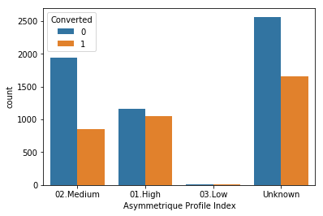

```python
sns.countplot(lead['Asymmetrique Profile Index'], hue = lead['Converted'])
```

```python
lead['Asymmetrique Profile Score'].unique()
```

```
array([15., 20., 17., 18., 14., 16., 13., 19., 12., nan, 11.])
```

- Imputing null values of Score with -999 as these null values have some importance.
- Now this value and combining with the Unknown value in Index column together we will use them for modelling purpose.

```python
lead['Asymmetrique Activity Score'].fillna(-999, inplace = True)
lead['Asymmetrique Profile Score'].fillna(-999, inplace = True)
```

```python
lead.isnull().sum()[lead.isnull().sum()>0]/len(lead)
```

```
Lead Source             0.003896
TotalVisits             0.014827
Page Views Per Visit    0.014827
Last Activity           0.011147
dtype: float64
```

- Removing these rows because they are very less in number.

```python
lead.dropna(inplace = True)
```

```python
lead.isnull().sum()
```

[output not shown]

### Data Preparation

```python
lead.head()
```

[output not shown]

##### Dropping Prospect ID and Lead Number columns, as they are ids which will not be of use in modelling.

- Also dropping columns which have only one value;['Magazine', 'Receive More Updates About Our Courses', 'Update me on Supply Chain Content', 'Get updates on DM Content', 'I agree to pay the amount through cheque']

```python
lead.drop(columns = ['Prospect ID', 'Lead Number'], inplace = True)
lead.drop(columns = ['Magazine', 'Receive More Updates About Our Courses', 'Update me on Supply Chain Content',
              'Get updates on DM Content', 'I agree to pay the amount through cheque'], inplace = True)
```

```python
lead.head(2)
```

[output not shown]

###### Converting binary Yes and NO to 1 and 0.

```python
lead[['Do Not Email', 'Do Not Call', 'Search', 'Newspaper Article', 'X Education Forums', 'Newspaper',
      'Digital Advertisement', 'Through Recommendations', 'A free copy of Mastering The Interview']].head()
```

|  | Do Not Email | Do Not Call | Search | Newspaper Article | X Education Forums | Newspaper | Digital Advertisement | Through Recommendations | A free copy of Mastering The Interview |
| --- | --- | --- | --- | --- | --- | --- | --- | --- | --- |
| 0 | No | No | No | No | No | No | No | No | No |
| 1 | No | No | No | No | No | No | No | No | No |
| 2 | No | No | No | No | No | No | No | No | Yes |
| 3 | No | No | No | No | No | No | No | No | No |
| 4 | No | No | No | No | No | No | No | No | No |

```python
lead.groupby('Do Not Call')['Converted'].value_counts()
```

```
Do Not Call  Converted
No           0            5639
             1            3433
Yes          1               2
Name: Converted, dtype: int64
```

- This is of not much use. We will keep it and treat it in feature selection.

```python
lead.groupby('Search')['Converted'].value_counts(normalize = True), lead.groupby('Search')['Converted'].value_counts()
```

```
(Search  Converted
 No      0            0.621413
         1            0.378587
 Yes     0            0.642857
         1            0.357143
 Name: Converted, dtype: float64, Search  Converted
 No      0            5630
         1            3430
 Yes     0               9
         1               5
 Name: Converted, dtype: int64)
```

- This is also of not much use. We will keep it and treat it in feature selection.

```python
lead.groupby('Newspaper Article')['Converted'].value_counts()
```

```
Newspaper Article  Converted
No                 0            5638
                   1            3434
Yes                0               1
                   1               1
Name: Converted, dtype: int64
```

- This is also of not much use. We will keep it and treat it in feature selection.

```python
lead.groupby('X Education Forums')['Converted'].value_counts()
```

```
X Education Forums  Converted
No                  0            5638
                    1            3435
Yes                 0               1
Name: Converted, dtype: int64
```

- This is also of not much use. We will keep it and treat it in feature selection.

```python
lead.groupby('Newspaper')['Converted'].value_counts()
```

```
Newspaper  Converted
No         0            5638
           1            3435
Yes        0               1
Name: Converted, dtype: int64
```

- This is also of not much use. We will keep it and treat it in feature selection.

```python
lead.groupby('Digital Advertisement')['Converted'].value_counts()
```

```
Digital Advertisement  Converted
No                     0            5636
                       1            3434
Yes                    0               3
                       1               1
Name: Converted, dtype: int64
```

- This is also of not much use. We will keep it and treat it in feature selection.

```python
lead.groupby('Through Recommendations')['Converted'].value_counts()
```

```
Through Recommendations  Converted
No                       0            5637
                         1            3430
Yes                      1               5
                         0               2
Name: Converted, dtype: int64
```

- This is also of not much use. We will keep it and treat it in feature selection.

*The above variables are not much of use individually but they can be of use in combinations.*

###### Converting binary Yes and NO to 1 and 0.

```python
lead[['Do Not Email', 'Do Not Call', 'Search', 'Newspaper Article', 'X Education Forums', 'Newspaper',
      'Digital Advertisement', 'Through Recommendations', 'A free copy of Mastering The Interview']] =lead[['Do Not Email',
    'Do Not Call', 'Search', 'Newspaper Article', 'X Education Forums', 'Newspaper', 'Digital Advertisement',
    'Through Recommendations', 'A free copy of Mastering The Interview']].apply(lambda x : x.map({'Yes':1, 'No':0}))
```

```python
lead.head(2)
```

|  | Lead Origin | Lead Source | Do Not Email | Converted | TotalVisits | Total Time Spent on Website | Page Views Per Visit | Last Activity | Country | Specialization | How did you hear about X Education | What is your current occupation | What matters most to you in choosing a course | Search | Newspaper Article | X Education Forums | Newspaper | Digital Advertisement | Through Recommendations | Tags | Lead Quality | Lead Profile | City | Asymmetrique Activity Index | Asymmetrique Profile Index | Asymmetrique Activity Score | Asymmetrique Profile Score | A free copy of Mastering The Interview | Last Notable Activity |
| --- | --- | --- | --- | --- | --- | --- | --- | --- | --- | --- | --- | --- | --- | --- | --- | --- | --- | --- | --- | --- | --- | --- | --- | --- | --- | --- | --- | --- | --- |
| 0 | API | Olark Chat | 0 | 0 | 0.0 | 0 | 0.0 | Page Visited on Website | Unknown | Select | Select | Unemployed | Better Career Prospects | 0 | 0 | 0 | 0 | 0 | 0 | Interested in other courses | Low in Relevance | Select | Select | 02.Medium | 02.Medium | 15.0 | 15.0 | 0 | Modified |
| 1 | API | Organic Search | 0 | 0 | 5.0 | 674 | 2.5 | Email Opened | India | Select | Select | Unemployed | Better Career Prospects | 0 | 0 | 0 | 0 | 0 | 0 | Ringing | Unknown | Select | Select | 02.Medium | 02.Medium | 15.0 | 15.0 | 0 | Email Opened |

###### The information of columns Asymmetrique Activity and Profile index is there in the score of the respective columns. But we will keep the unknown value in of the these columns as it denotes the null values of the score column.

```python
lead['Asymmetrique Activity Index'].unique()
```

```
array(['02.Medium', '01.High', '03.Low', 'Unknown'], dtype=object)
```

```python
lead[['Asymmetrique Activity Unknown', 'Asymmetrique Profile Unknown']] = lead[['Asymmetrique Activity Index',
    'Asymmetrique Profile Index']].apply(lambda x : x.map({'Unknown':1, '02.Medium':0, '01.High': 0, '03.Low':0}))
```

```python
lead.head(2)
```

[output not shown]

#### Outlier Treatment

```python
lead[['TotalVisits', 'Total Time Spent on Website', 'Page Views Per Visit', 'Asymmetrique Activity Score',
      'Asymmetrique Profile Score']].describe(percentiles = [0.1,0.2,0.25,0.3,0.5,0.6,0.75,0.8,0.9,0.99])
```

|  | TotalVisits | Total Time Spent on Website | Page Views Per Visit | Asymmetrique Activity Score | Asymmetrique Profile Score |
| --- | --- | --- | --- | --- | --- |
| count | 9074.000000 | 9074.000000 | 9074.000000 | 9074.000000 | 9074.000000 |
| mean | 3.456028 | 482.887481 | 2.370151 | -449.460326 | -448.363566 |
| std | 4.858802 | 545.256560 | 2.160871 | 504.868375 | 505.876678 |
| min | 0.000000 | 0.000000 | 0.000000 | -999.000000 | -999.000000 |
| 10% | 0.000000 | 0.000000 | 0.000000 | -999.000000 | -999.000000 |
| 20% | 0.000000 | 0.000000 | 0.000000 | -999.000000 | -999.000000 |
| 25% | 1.000000 | 11.000000 | 1.000000 | -999.000000 | -999.000000 |
| 30% | 2.000000 | 55.000000 | 1.000000 | -999.000000 | -999.000000 |
| 50% | 3.000000 | 246.000000 | 2.000000 | 13.000000 | 14.000000 |
| 60% | 3.000000 | 367.000000 | 2.500000 | 14.000000 | 15.000000 |
| 75% | 5.000000 | 922.750000 | 3.200000 | 14.000000 | 16.000000 |
| 80% | 5.000000 | 1078.400000 | 4.000000 | 15.000000 | 17.000000 |
| 90% | 7.000000 | 1373.000000 | 5.000000 | 15.000000 | 18.000000 |
| 99% | 17.000000 | 1839.000000 | 9.000000 | 17.000000 | 20.000000 |
| max | 251.000000 | 2272.000000 | 55.000000 | 18.000000 | 20.000000 |

- TotalVisits is highly skewed.
- Page Views Per Visit is also highly skewed.

```python
lead['TotalVisits'].value_counts()
```

```
0.0      2161
2.0      1679
3.0      1306
4.0      1120
5.0       783
6.0       466
1.0       395
7.0       309
8.0       224
9.0       164
10.0      114
11.0       86
13.0       48
12.0       45
14.0       36
16.0       21
15.0       18
17.0       16
18.0       15
20.0       12
19.0        9
23.0        6
21.0        6
27.0        5
24.0        5
25.0        5
22.0        3
28.0        2
29.0        2
26.0        2
251.0       1
74.0        1
30.0        1
141.0       1
54.0        1
41.0        1
115.0       1
43.0        1
42.0        1
32.0        1
55.0        1
Name: TotalVisits, dtype: int64
```

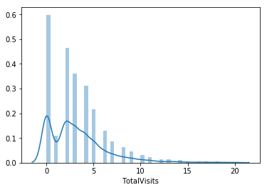

```python
sns.distplot(lead[lead['TotalVisits']<=20]['TotalVisits'])
```

- We can remove those values which are greater than 20.

```python
lead = lead[lead['TotalVisits']<=20]
```

```python
lead[lead['Page Views Per Visit']>10]['Page Views Per Visit'].value_counts()
```

```
11.00    18
14.00     9
13.00     6
12.00     5
15.00     4
16.00     3
12.33     1
11.50     1
14.50     1
24.00     1
55.00     1
Name: Page Views Per Visit, dtype: int64
```

- Removing rows those values which are greater than 20.

```python
lead = lead[lead['Page Views Per Visit']<=20]
```

```python
lead.shape
```

```
(9027, 28)
```

##### Encoding the cat variables

```python
#plt.figure(figsize = (15,8))
#sns.countplot(lead['Lead Source'])
lead.groupby(['Lead Source'])['Converted'].value_counts()
```

```
Lead Source        Converted
Click2call         1               3
                   0               1
Direct Traffic     0            1725
                   1             818
Facebook           0              22
                   1               9
Google             0            1721
                   1            1147
Live Chat          1               2
NC_EDM             1               1
Olark Chat         0            1305
                   1             448
Organic Search     0             718
                   1             436
Pay per Click Ads  0               1
Press_Release      0               2
Reference          1             410
                   0              33
Referral Sites     0              94
                   1              31
Social Media       0               1
                   1               1
WeLearn            1               1
Welingak Website   1             127
                   0               2
bing               0               5
                   1               1
blog               0               1
google             0               5
testone            0               1
welearnblog_Home   0               1
youtubechannel     0               1
Name: Converted, dtype: int64
```

```python
# Putting all the values in Lead Source which are very less in number to Others category as this will increase redundancy
lead['Lead Source'].replace(['google','welearnblog_Home', 'blog', 'testone', 'youtubechannel', 'Pay per Click Ads',
                            'Press_Release', 'Social Media', 'bing', 'WeLearn', 'NC_EDM', 'Live Chat', 'Click2call'],
                            ['Google', 'Others', 'Others', 'Others', 'Others', 'Others', 'Others','Others','Others',
                             'Others', 'Others', 'Others', 'Others'], inplace = True)
```

```python
lead['Last Activity'].value_counts()
```

```
Email Opened                 3418
SMS Sent                     2708
Olark Chat Conversation       971
Page Visited on Website       618
Converted to Lead             428
Email Bounced                 312
Email Link Clicked            266
Form Submitted on Website     116
Unreachable                    90
Unsubscribed                   59
Had a Phone Conversation       25
Others                         16
Name: Last Activity, dtype: int64
```

```python
# Putting all the values in Lead Source which are very less in number to Others category as this will increase redundancy
lead['Last Activity'].replace(['View in browser link Clicked','Approached upfront', 'Email Marked Spam', 'Email Received',
                               'Resubscribed to emails', 'Visited Booth in Tradeshow'],
                            ['Others', 'Others', 'Others', 'Others', 'Others', 'Others'], inplace = True)
```

```python
lead['Last Activity'].value_counts()
```

[output not shown]

```python
count = lead['Country'].value_counts()
idx = count[count.lt(10)].index
lead.loc[lead['Country'].isin(idx), 'Country'] = 'Others'
```

```python
lead['Country'].value_counts()
```

```
India                   6446
Unknown                 2296
Others                    81
United States             68
United Arab Emirates      53
Singapore                 24
Saudi Arabia              21
United Kingdom            15
Australia                 13
Qatar                     10
Name: Country, dtype: int64
```

```python
lead['Tags'].value_counts()
```

```
Unknown                                              3327
Will revert after reading the email                  2016
Ringing                                              1187
Interested in other courses                           509
Already a student                                     465
Closed by Horizzon                                    301
switched off                                          240
Busy                                                  185
Lost to EINS                                          172
Not doing further education                           145
Interested  in full time MBA                          116
Graduation in progress                                111
invalid number                                         83
Diploma holder (Not Eligible)                          63
wrong number given                                     47
opp hangup                                             33
number not provided                                    25
in touch with EINS                                     12
Lost to Others                                          7
Still Thinking                                          6
Want to take admission but has financial problems       6
In confusion whether part time or DLP                   5
Interested in Next batch                                5
Lateral student                                         3
University not recognized                               2
Shall take in the next coming month                     2
Recognition issue (DEC approval)                        1
Name: Tags, dtype: int64
```

```python
count = lead['Tags'].value_counts()
idx = count[count.lt(10)].index
lead.loc[lead['Tags'].isin(idx), 'Tags'] = 'Others'
```

```python
lead['Tags'].value_counts()
```

[output not shown]

```python
dummy1 = pd.get_dummies(lead[['Lead Origin', 'Lead Source', 'Last Activity', 'Country', 'Specialization', 'How did you hear about X Education',
     'What is your current occupation', 'Tags', 'Lead Quality',
      'Lead Profile', 'City', 'Last Notable Activity']])
```

```python
lead.drop(columns = ['Asymmetrique Activity Index', 'Asymmetrique Profile Index'], inplace = True)
```

```python
lead.info()
```

[output not shown]

```python
dummy_lead = pd.get_dummies(lead, drop_first = True)
len(dummy_lead.columns)
```

```
133
```

### Train Test Split

```python
df_train, df_test = train_test_split(dummy_lead, stratify = dummy_lead['Converted'],test_size = 0.3, random_state = 42)
df_train = pd.DataFrame(df_train, columns = dummy_lead.columns)
df_test = pd.DataFrame(df_test, columns = dummy_lead.columns)
df_train.head()
```

|  | Do Not Email | Converted | TotalVisits | Total Time Spent on Website | Page Views Per Visit | Search | Newspaper Article | X Education Forums | Newspaper | Digital Advertisement | Through Recommendations | Asymmetrique Activity Index | Asymmetrique Profile Index | Asymmetrique Activity Score | Asymmetrique Profile Score | A free copy of Mastering The Interview | Lead Origin_Landing Page Submission | Lead Origin_Lead Add Form | Lead Origin_Lead Import | Lead Source_Facebook | Lead Source_Google | Lead Source_Olark Chat | Lead Source_Organic Search | Lead Source_Others | Lead Source_Reference | Lead Source_Referral Sites | Lead Source_Welingak Website | Last Activity_Email Bounced | Last Activity_Email Link Clicked | … |
| --- | --- | --- | --- | --- | --- | --- | --- | --- | --- | --- | --- | --- | --- | --- | --- | --- | --- | --- | --- | --- | --- | --- | --- | --- | --- | --- | --- | --- | --- | --- |
| 1636 | 0 | 0 | 0.0 | 0 | 0.0 | 0 | 0 | 0 | 0 | 0 | 0 | 0 | 0 | 11.0 | 12.0 | 0 | 0 | 0 | 1 | 1 | 0 | 0 | 0 | 0 | 0 | 0 | 0 | 0 | 0 | … |
| 4922 | 0 | 1 | 3.0 | 1742 | 3.0 | 0 | 0 | 0 | 0 | 0 | 0 | 1 | 1 | -999.0 | -999.0 | 1 | 1 | 0 | 0 | 0 | 0 | 0 | 0 | 0 | 0 | 0 | 0 | 0 | 0 | … |
| 583 | 0 | 0 | 2.0 | 156 | 2.0 | 0 | 0 | 0 | 0 | 0 | 0 | 0 | 0 | 14.0 | 15.0 | 0 | 0 | 0 | 0 | 0 | 1 | 0 | 0 | 0 | 0 | 0 | 0 | 0 | 0 | … |
| 2704 | 0 | 0 | 3.0 | 1314 | 3.0 | 0 | 0 | 0 | 0 | 0 | 0 | 1 | 1 | -999.0 | -999.0 | 0 | 1 | 0 | 0 | 0 | 1 | 0 | 0 | 0 | 0 | 0 | 0 | 0 | 0 | … |
| 6042 | 0 | 0 | 2.0 | 4 | 2.0 | 0 | 0 | 0 | 0 | 0 | 0 | 1 | 1 | -999.0 | -999.0 | 0 | 0 | 0 | 0 | 0 | 1 | 0 | 0 | 0 | 0 | 0 | 0 | 0 | 0 | … |

#### Feature Scaling

```python
scaler = StandardScaler()
df_train[['TotalVisits', 'Total Time Spent on Website', 'Page Views Per Visit', 'Asymmetrique Activity Score',
          'Asymmetrique Profile Score']] = scaler.fit_transform(df_train[['TotalVisits', 'Total Time Spent on Website', 'Page Views Per Visit',
                                                     'Asymmetrique Activity Score', 'Asymmetrique Profile Score']])
df_test[['TotalVisits', 'Total Time Spent on Website', 'Page Views Per Visit', 'Asymmetrique Activity Score',
          'Asymmetrique Profile Score']] = scaler.transform(df_test[['TotalVisits', 'Total Time Spent on Website', 'Page Views Per Visit',
                                                     'Asymmetrique Activity Score', 'Asymmetrique Profile Score']])
```

```python
X_train = df_train.drop(columns = 'Converted')
y_train = df_train['Converted']
X_test = df_test.drop(columns = 'Converted')
y_test = df_test['Converted']
```

```python
# Conversion rate
dummy_lead['Converted'].value_counts(normalize = True)*100
```

```
0    62.169048
1    37.830952
Name: Converted, dtype: float64
```

*37.83% of customers get converted. Data is not much imbalanced. We can proceed.*

# Model Building

```python
lr = LogisticRegression()
lr.fit(X_train,y_train)
y_pred_train = lr.predict(X_train)
y_pred_test = lr.predict(X_test)
```

```python
print(metrics.classification_report(y_train, y_pred_train))
print(metrics.confusion_matrix(y_train,y_pred_train))
print(metrics.classification_report(y_test, y_pred_test))
print(metrics.confusion_matrix(y_test,y_pred_test))
```

```
              precision    recall  f1-score   support

           0       0.94      0.96      0.95      3928
           1       0.94      0.89      0.92      2390

   micro avg       0.94      0.94      0.94      6318
   macro avg       0.94      0.93      0.93      6318
weighted avg       0.94      0.94      0.94      6318

[[3782  146]
 [ 251 2139]]
              precision    recall  f1-score   support

           0       0.94      0.97      0.96      1684
           1       0.95      0.90      0.93      1025

   micro avg       0.94      0.94      0.94      2709
   macro avg       0.95      0.94      0.94      2709
weighted avg       0.94      0.94      0.94      2709

[[1633   51]
 [  99  926]]
```

#### Feature Selection

```python
lr = LogisticRegression()
rfe = RFE(lr,20)
rfe.fit(X_train,y_train)
```

[output not shown]

[output cut: 171 more lines]

[output not shown]

```
RFE(estimator=LogisticRegression(C=1.0, class_weight=None, dual=False, fit_intercept=True,
          intercept_scaling=1, max_iter=100, multi_class='warn',
          n_jobs=None, penalty='l2', random_state=None, solver='warn',
          tol=0.0001, verbose=0, warm_start=False),
  n_features_to_select=20, step=1, verbose=0)
```

```python
list(zip(rfe.ranking_,df_train.drop(columns = 'Converted').columns, rfe.support_))
```

```
[(5, 'Do Not Email', False),
 (71, 'TotalVisits', False),
 (2, 'Total Time Spent on Website', False),
 (93, 'Page Views Per Visit', False),
 (22, 'Search', False),
 (106, 'Newspaper Article', False),
 (84, 'X Education Forums', False),
 (88, 'Newspaper', False),
 (64, 'Digital Advertisement', False),
 (109, 'Through Recommendations', False),
 (66, 'Asymmetrique Activity Index', False),
 (65, 'Asymmetrique Profile Index', False),
 (86, 'Asymmetrique Activity Score', False),
 (67, 'Asymmetrique Profile Score', False),
 (79, 'A free copy of Mastering The Interview', False),
 (17, 'Lead Origin_Landing Page Submission', False),
 (49, 'Lead Origin_Lead Add Form', False),
 (16, 'Lead Origin_Lead Import', False),
 (8, 'Lead Source_Facebook', False),
 (105, 'Lead Source_Google', False),
 (50, 'Lead Source_Olark Chat', False),
 (44, 'Lead Source_Organic Search', False),
 (83, 'Lead Source_Others', False),
 (75, 'Lead Source_Reference', False),
 (87, 'Lead Source_Referral Sites', False),
 (1, 'Lead Source_Welingak Website', True),
 (53, 'Last Activity_Email Bounced', False),
 (102, 'Last Activity_Email Link Clicked', False),
 (81, 'Last Activity_Email Opened', False),
 (21, 'Last Activity_Form Submitted on Website', False),
 (33, 'Last Activity_Had a Phone Conversation', False),
 (11, 'Last Activity_Olark Chat Conversation', False),
 (72, 'Last Activity_Others', False),
 (61, 'Last Activity_Page Visited on Website', False),
 (1, 'Last Activity_SMS Sent', True),
 (26, 'Last Activity_Unreachable', False),
 (15, 'Last Activity_Unsubscribed', False),
 (34, 'Country_India', False),
 (110, 'Country_Others', False),
 (10, 'Country_Qatar', False),
```

[output cut: 77 more lines]

```
 (100, 'Last Notable Activity_Email Bounced', False),
 (3, 'Last Notable Activity_Email Link Clicked', False),
 (89, 'Last Notable Activity_Email Marked Spam', False),
 (82, 'Last Notable Activity_Email Opened', False),
 (101, 'Last Notable Activity_Email Received', False),
 (112, 'Last Notable Activity_Form Submitted on Website', False),
 (63, 'Last Notable Activity_Had a Phone Conversation', False),
 (1, 'Last Notable Activity_Modified', True),
 (25, 'Last Notable Activity_Olark Chat Conversation', False),
 (85, 'Last Notable Activity_Page Visited on Website', False),
 (113, 'Last Notable Activity_Resubscribed to emails', False),
 (12, 'Last Notable Activity_SMS Sent', False),
 (42, 'Last Notable Activity_Unreachable', False),
 (4, 'Last Notable Activity_Unsubscribed', False),
 (95, 'Last Notable Activity_View in browser link Clicked', False)]
```

```python
col = X_train.columns[rfe.support_]
col
```

```
Index(['Lead Source_Welingak Website', 'Last Activity_SMS Sent',
       'Country_Unknown', 'What is your current occupation_Unknown',
       'Tags_Busy', 'Tags_Closed by Horizzon', 'Tags_Lost to EINS',
       'Tags_Not doing further education', 'Tags_Ringing', 'Tags_Unknown',
       'Tags_Will revert after reading the email', 'Tags_invalid number',
       'Tags_number not provided', 'Tags_switched off',
       'Tags_wrong number given', 'Lead Quality_Worst', 'Lead Profile_Select',
       'Lead Profile_Student of SomeSchool', 'Lead Profile_Unknown',
       'Last Notable Activity_Modified'],
      dtype='object')
```

#### Model after RFE

```python
lr = LogisticRegression()
lr.fit(X_train[col],y_train)
y_pred_train = lr.predict(X_train[col])
y_pred_test = lr.predict(X_test[col])
```

```python
print(metrics.classification_report(y_train, y_pred_train))
print(metrics.confusion_matrix(y_train,y_pred_train))
print(metrics.classification_report(y_test, y_pred_test))
print(metrics.confusion_matrix(y_test,y_pred_test))
```

```
              precision    recall  f1-score   support

           0       0.92      0.96      0.94      3928
           1       0.93      0.87      0.90      2390

   micro avg       0.92      0.92      0.92      6318
   macro avg       0.93      0.91      0.92      6318
weighted avg       0.93      0.92      0.92      6318

[[3765  163]
 [ 311 2079]]
              precision    recall  f1-score   support

           0       0.91      0.96      0.94      1684
           1       0.93      0.85      0.89      1025

   micro avg       0.92      0.92      0.92      2709
   macro avg       0.92      0.91      0.91      2709
weighted avg       0.92      0.92      0.92      2709

[[1621   63]
 [ 152  873]]
```

```python
# Using Statsmodels library
X_train_sm = sm.add_constant(X_train[col])
model = sm.GLM(y_train,X_train_sm, family = sm.families.Binomial()).fit()
model.summary()
```

Generalized Linear Model Regression Results

| Dep. Variable: | Converted | No. Observations: | 6318 |
| --- | --- | --- | --- |
| Model: | GLM | Df Residuals: | 6297 |
| Model Family: | Binomial | Df Model: | 20 |
| Link Function: | logit | Scale: | 1.0000 |
| Method: | IRLS | Log-Likelihood: | -1216.4 |
| Date: | Fri, 01 Nov 2019 | Deviance: | 2432.9 |
| Time: | 22:24:09 | Pearson chi2: | 1.30e+04 |
| No. Iterations: | 24 | Covariance Type: | nonrobust |

|  | coef | std err | z | P>\|z\| | [0.025 | 0.975] |
| --- | --- | --- | --- | --- | --- | --- |
| const | -1.7920 | 0.235 | -7.628 | 0.000 | -2.252 | -1.332 |
| Lead Source_Welingak Website | 2.3841 | 0.745 | 3.201 | 0.001 | 0.924 | 3.844 |
| Last Activity_SMS Sent | 2.1643 | 0.122 | 17.687 | 0.000 | 1.924 | 2.404 |
| Country_Unknown | -0.1535 | 0.130 | -1.182 | 0.237 | -0.408 | 0.101 |
| What is your current occupation_Unknown | 22.4780 | 6.2e+04 | 0.000 | 1.000 | -1.22e+05 | 1.22e+05 |
| Tags_Busy | 1.8795 | 0.296 | 6.340 | 0.000 | 1.298 | 2.460 |
| Tags_Closed by Horizzon | 8.1363 | 0.746 | 10.910 | 0.000 | 6.675 | 9.598 |
| Tags_Lost to EINS | 9.2938 | 0.681 | 13.638 | 0.000 | 7.958 | 10.630 |
| Tags_Not doing further education | -21.7116 | 1.91e+04 | -0.001 | 0.999 | -3.74e+04 | 3.73e+04 |
| Tags_Ringing | -1.8654 | 0.295 | -6.315 | 0.000 | -2.444 | -1.286 |
| Tags_Unknown | 3.3885 | 0.245 | 13.816 | 0.000 | 2.908 | 3.869 |
| Tags_Will revert after reading the email | 5.6333 | 0.255 | 22.049 | 0.000 | 5.133 | 6.134 |
| Tags_invalid number | -23.3383 | 2.44e+04 | -0.001 | 0.999 | -4.78e+04 | 4.77e+04 |
| Tags_number not provided | -23.6372 | 4.61e+04 | -0.001 | 1.000 | -9.04e+04 | 9.04e+04 |
| Tags_switched off | -2.5947 | 0.630 | -4.121 | 0.000 | -3.829 | -1.361 |
| Tags_wrong number given | -23.9659 | 3.36e+04 | -0.001 | 0.999 | -6.58e+04 | 6.58e+04 |
| Lead Quality_Worst | -2.9806 | 0.928 | -3.212 | 0.001 | -4.799 | -1.162 |
| Lead Profile_Select | -1.1593 | 0.194 | -5.989 | 0.000 | -1.539 | -0.780 |
| Lead Profile_Student of SomeSchool | -1.9092 | 1.105 | -1.727 | 0.084 | -4.076 | 0.257 |
| Lead Profile_Unknown | -26.2138 | 6.2e+04 | -0.000 | 1.000 | -1.22e+05 | 1.22e+05 |
| Last Notable Activity_Modified | -1.5672 | 0.127 | -12.303 | 0.000 | -1.817 | -1.318 |

```python
# Dropping 'What is your current occupation_Unknown' and building the model again
X_train_sm = X_train_sm.drop(columns = 'What is your current occupation_Unknown')
model = sm.GLM(y_train,X_train_sm, family = sm.families.Binomial()).fit()
model.summary()
```

Generalized Linear Model Regression Results

| Dep. Variable: | Converted | No. Observations: | 6318 |
| --- | --- | --- | --- |
| Model: | GLM | Df Residuals: | 6298 |
| Model Family: | Binomial | Df Model: | 19 |
| Link Function: | logit | Scale: | 1.0000 |
| Method: | IRLS | Log-Likelihood: | -1217.0 |
| Date: | Fri, 01 Nov 2019 | Deviance: | 2433.9 |
| Time: | 22:27:26 | Pearson chi2: | 1.31e+04 |
| No. Iterations: | 24 | Covariance Type: | nonrobust |

|  | coef | std err | z | P>\|z\| | [0.025 | 0.975] |
| --- | --- | --- | --- | --- | --- | --- |
| const | -1.7912 | 0.235 | -7.624 | 0.000 | -2.252 | -1.331 |
| Lead Source_Welingak Website | 2.3832 | 0.745 | 3.199 | 0.001 | 0.923 | 3.843 |
| Last Activity_SMS Sent | 2.1655 | 0.122 | 17.698 | 0.000 | 1.926 | 2.405 |
| Country_Unknown | -0.1516 | 0.130 | -1.167 | 0.243 | -0.406 | 0.103 |
| Tags_Busy | 1.8788 | 0.297 | 6.337 | 0.000 | 1.298 | 2.460 |
| Tags_Closed by Horizzon | 8.1385 | 0.746 | 10.912 | 0.000 | 6.677 | 9.600 |
| Tags_Lost to EINS | 9.2987 | 0.682 | 13.644 | 0.000 | 7.963 | 10.634 |
| Tags_Not doing further education | -21.7109 | 1.91e+04 | -0.001 | 0.999 | -3.74e+04 | 3.73e+04 |
| Tags_Ringing | -1.8670 | 0.295 | -6.320 | 0.000 | -2.446 | -1.288 |
| Tags_Unknown | 3.3880 | 0.245 | 13.812 | 0.000 | 2.907 | 3.869 |
| Tags_Will revert after reading the email | 5.6342 | 0.256 | 22.047 | 0.000 | 5.133 | 6.135 |
| Tags_invalid number | -23.3395 | 2.44e+04 | -0.001 | 0.999 | -4.78e+04 | 4.77e+04 |
| Tags_number not provided | -23.6383 | 4.61e+04 | -0.001 | 1.000 | -9.04e+04 | 9.03e+04 |
| Tags_switched off | -2.5963 | 0.630 | -4.123 | 0.000 | -3.830 | -1.362 |
| Tags_wrong number given | -23.9673 | 3.36e+04 | -0.001 | 0.999 | -6.58e+04 | 6.58e+04 |
| Lead Quality_Worst | -2.9817 | 0.928 | -3.212 | 0.001 | -4.801 | -1.162 |
| Lead Profile_Select | -1.1595 | 0.194 | -5.990 | 0.000 | -1.539 | -0.780 |
| Lead Profile_Student of SomeSchool | -1.9083 | 1.105 | -1.726 | 0.084 | -4.075 | 0.258 |
| Lead Profile_Unknown | -3.7391 | 0.244 | -15.316 | 0.000 | -4.218 | -3.261 |
| Last Notable Activity_Modified | -1.5715 | 0.127 | -12.342 | 0.000 | -1.821 | -1.322 |

```python
# Dropping 'Tags_number not provided' and building the model again
X_train_sm = X_train_sm.drop(columns = 'Tags_number not provided')
model = sm.GLM(y_train,X_train_sm, family = sm.families.Binomial()).fit()
model.summary()
```

Generalized Linear Model Regression Results

| Dep. Variable: | Converted | No. Observations: | 6318 |
| --- | --- | --- | --- |
| Model: | GLM | Df Residuals: | 6299 |
| Model Family: | Binomial | Df Model: | 18 |
| Link Function: | logit | Scale: | 1.0000 |
| Method: | IRLS | Log-Likelihood: | -1219.5 |
| Date: | Fri, 01 Nov 2019 | Deviance: | 2439.1 |
| Time: | 22:28:30 | Pearson chi2: | 1.30e+04 |
| No. Iterations: | 24 | Covariance Type: | nonrobust |

|  | coef | std err | z | P>\|z\| | [0.025 | 0.975] |
| --- | --- | --- | --- | --- | --- | --- |
| const | -1.8591 | 0.236 | -7.865 | 0.000 | -2.322 | -1.396 |
| Lead Source_Welingak Website | 2.3804 | 0.745 | 3.196 | 0.001 | 0.921 | 3.840 |
| Last Activity_SMS Sent | 2.1500 | 0.122 | 17.653 | 0.000 | 1.911 | 2.389 |
| Country_Unknown | -0.1460 | 0.130 | -1.124 | 0.261 | -0.401 | 0.109 |
| Tags_Busy | 1.9774 | 0.295 | 6.704 | 0.000 | 1.399 | 2.556 |
| Tags_Closed by Horizzon | 8.2143 | 0.746 | 11.008 | 0.000 | 6.752 | 9.677 |
| Tags_Lost to EINS | 9.3754 | 0.681 | 13.766 | 0.000 | 8.041 | 10.710 |
| Tags_Not doing further education | -21.6294 | 1.91e+04 | -0.001 | 0.999 | -3.74e+04 | 3.74e+04 |
| Tags_Ringing | -1.7668 | 0.294 | -6.017 | 0.000 | -2.342 | -1.191 |
| Tags_Unknown | 3.4832 | 0.244 | 14.247 | 0.000 | 3.004 | 3.962 |
| Tags_Will revert after reading the email | 5.7157 | 0.256 | 22.340 | 0.000 | 5.214 | 6.217 |
| Tags_invalid number | -23.2389 | 2.44e+04 | -0.001 | 0.999 | -4.78e+04 | 4.78e+04 |
| Tags_switched off | -2.4969 | 0.629 | -3.970 | 0.000 | -3.730 | -1.264 |
| Tags_wrong number given | -23.8731 | 3.36e+04 | -0.001 | 0.999 | -6.58e+04 | 6.58e+04 |
| Lead Quality_Worst | -2.9529 | 0.934 | -3.161 | 0.002 | -4.784 | -1.122 |
| Lead Profile_Select | -1.1893 | 0.194 | -6.130 | 0.000 | -1.570 | -0.809 |
| Lead Profile_Student of SomeSchool | -1.9252 | 1.113 | -1.730 | 0.084 | -4.106 | 0.256 |
| Lead Profile_Unknown | -3.7632 | 0.244 | -15.395 | 0.000 | -4.242 | -3.284 |
| Last Notable Activity_Modified | -1.5612 | 0.127 | -12.268 | 0.000 | -1.811 | -1.312 |

```python
# Dropping 'Tags_Not doing further education' and building the model again
X_train_sm = X_train_sm.drop(columns = 'Tags_Not doing further education')
model = sm.GLM(y_train,X_train_sm, family = sm.families.Binomial()).fit()
model.summary()
```

Generalized Linear Model Regression Results

| Dep. Variable: | Converted | No. Observations: | 6318 |
| --- | --- | --- | --- |
| Model: | GLM | Df Residuals: | 6300 |
| Model Family: | Binomial | Df Model: | 17 |
| Link Function: | logit | Scale: | 1.0000 |
| Method: | IRLS | Log-Likelihood: | -1221.8 |
| Date: | Fri, 01 Nov 2019 | Deviance: | 2443.5 |
| Time: | 22:29:19 | Pearson chi2: | 1.31e+04 |
| No. Iterations: | 23 | Covariance Type: | nonrobust |

|  | coef | std err | z | P>\|z\| | [0.025 | 0.975] |
| --- | --- | --- | --- | --- | --- | --- |
| const | -1.9382 | 0.235 | -8.233 | 0.000 | -2.400 | -1.477 |
| Lead Source_Welingak Website | 2.3797 | 0.745 | 3.195 | 0.001 | 0.920 | 3.839 |
| Last Activity_SMS Sent | 2.1501 | 0.122 | 17.663 | 0.000 | 1.912 | 2.389 |
| Country_Unknown | -0.1451 | 0.130 | -1.117 | 0.264 | -0.400 | 0.109 |
| Tags_Busy | 2.0561 | 0.294 | 6.989 | 0.000 | 1.480 | 2.633 |
| Tags_Closed by Horizzon | 8.2970 | 0.746 | 11.123 | 0.000 | 6.835 | 9.759 |
| Tags_Lost to EINS | 9.4673 | 0.682 | 13.885 | 0.000 | 8.131 | 10.804 |
| Tags_Ringing | -1.6885 | 0.293 | -5.766 | 0.000 | -2.262 | -1.115 |
| Tags_Unknown | 3.5618 | 0.244 | 14.614 | 0.000 | 3.084 | 4.040 |
| Tags_Will revert after reading the email | 5.7952 | 0.255 | 22.723 | 0.000 | 5.295 | 6.295 |
| Tags_invalid number | -22.1580 | 1.48e+04 | -0.001 | 0.999 | -2.9e+04 | 2.89e+04 |
| Tags_switched off | -2.4185 | 0.629 | -3.847 | 0.000 | -3.651 | -1.186 |
| Tags_wrong number given | -22.7924 | 2.03e+04 | -0.001 | 0.999 | -3.99e+04 | 3.99e+04 |
| Lead Quality_Worst | -3.0180 | 0.917 | -3.293 | 0.001 | -4.814 | -1.222 |
| Lead Profile_Select | -1.1882 | 0.194 | -6.133 | 0.000 | -1.568 | -0.808 |
| Lead Profile_Student of SomeSchool | -1.8871 | 1.118 | -1.688 | 0.091 | -4.079 | 0.305 |
| Lead Profile_Unknown | -3.7623 | 0.244 | -15.404 | 0.000 | -4.241 | -3.284 |
| Last Notable Activity_Modified | -1.5650 | 0.127 | -12.300 | 0.000 | -1.814 | -1.316 |

```python
# Dropping 'Tags_invalid number' and building the model again
X_train_sm = X_train_sm.drop(columns = 'Tags_invalid number')
model = sm.GLM(y_train,X_train_sm, family = sm.families.Binomial()).fit()
model.summary()
```

Generalized Linear Model Regression Results

| Dep. Variable: | Converted | No. Observations: | 6318 |
| --- | --- | --- | --- |
| Model: | GLM | Df Residuals: | 6301 |
| Model Family: | Binomial | Df Model: | 16 |
| Link Function: | logit | Scale: | 1.0000 |
| Method: | IRLS | Log-Likelihood: | -1227.2 |
| Date: | Fri, 01 Nov 2019 | Deviance: | 2454.4 |
| Time: | 22:30:02 | Pearson chi2: | 1.31e+04 |
| No. Iterations: | 22 | Covariance Type: | nonrobust |

|  | coef | std err | z | P>\|z\| | [0.025 | 0.975] |
| --- | --- | --- | --- | --- | --- | --- |
| const | -2.0924 | 0.237 | -8.812 | 0.000 | -2.558 | -1.627 |
| Lead Source_Welingak Website | 2.3788 | 0.744 | 3.196 | 0.001 | 0.920 | 3.838 |
| Last Activity_SMS Sent | 2.1226 | 0.121 | 17.566 | 0.000 | 1.886 | 2.359 |
| Country_Unknown | -0.1422 | 0.130 | -1.097 | 0.273 | -0.396 | 0.112 |
| Tags_Busy | 2.2496 | 0.292 | 7.706 | 0.000 | 1.677 | 2.822 |
| Tags_Closed by Horizzon | 8.4571 | 0.747 | 11.326 | 0.000 | 6.994 | 9.921 |
| Tags_Lost to EINS | 9.6329 | 0.682 | 14.116 | 0.000 | 8.295 | 10.970 |
| Tags_Ringing | -1.4902 | 0.290 | -5.136 | 0.000 | -2.059 | -0.921 |
| Tags_Unknown | 3.7476 | 0.243 | 15.445 | 0.000 | 3.272 | 4.223 |
| Tags_Will revert after reading the email | 5.9630 | 0.256 | 23.325 | 0.000 | 5.462 | 6.464 |
| Tags_switched off | -2.2208 | 0.628 | -3.539 | 0.000 | -3.451 | -0.991 |
| Tags_wrong number given | -21.5998 | 1.23e+04 | -0.002 | 0.999 | -2.42e+04 | 2.42e+04 |
| Lead Quality_Worst | -3.0337 | 0.910 | -3.333 | 0.001 | -4.818 | -1.250 |
| Lead Profile_Select | -1.2207 | 0.194 | -6.287 | 0.000 | -1.601 | -0.840 |
| Lead Profile_Student of SomeSchool | -1.8833 | 1.131 | -1.665 | 0.096 | -4.101 | 0.334 |
| Lead Profile_Unknown | -3.7868 | 0.244 | -15.497 | 0.000 | -4.266 | -3.308 |
| Last Notable Activity_Modified | -1.5463 | 0.127 | -12.160 | 0.000 | -1.796 | -1.297 |

```python
# Dropping 'Tags_wrong number given' and building the model again
X_train_sm = X_train_sm.drop(columns = 'Tags_wrong number given')
model = sm.GLM(y_train,X_train_sm, family = sm.families.Binomial()).fit()
model.summary()
```

Generalized Linear Model Regression Results

| Dep. Variable: | Converted | No. Observations: | 6318 |
| --- | --- | --- | --- |
| Model: | GLM | Df Residuals: | 6302 |
| Model Family: | Binomial | Df Model: | 15 |
| Link Function: | logit | Scale: | 1.0000 |
| Method: | IRLS | Log-Likelihood: | -1231.5 |
| Date: | Fri, 01 Nov 2019 | Deviance: | 2463.0 |
| Time: | 22:30:30 | Pearson chi2: | 1.28e+04 |
| No. Iterations: | 9 | Covariance Type: | nonrobust |

|  | coef | std err | z | P>\|z\| | [0.025 | 0.975] |
| --- | --- | --- | --- | --- | --- | --- |
| const | -2.2305 | 0.238 | -9.368 | 0.000 | -2.697 | -1.764 |
| Lead Source_Welingak Website | 2.3784 | 0.744 | 3.197 | 0.001 | 0.920 | 3.837 |
| Last Activity_SMS Sent | 2.0979 | 0.120 | 17.452 | 0.000 | 1.862 | 2.334 |
| Country_Unknown | -0.1361 | 0.130 | -1.050 | 0.294 | -0.390 | 0.118 |
| Tags_Busy | 2.3879 | 0.291 | 8.201 | 0.000 | 1.817 | 2.959 |
| Tags_Closed by Horizzon | 8.5701 | 0.747 | 11.468 | 0.000 | 7.105 | 10.035 |
| Tags_Lost to EINS | 9.7311 | 0.683 | 14.255 | 0.000 | 8.393 | 11.069 |
| Tags_Ringing | -1.3442 | 0.289 | -4.652 | 0.000 | -1.911 | -0.778 |
| Tags_Unknown | 3.8684 | 0.244 | 15.871 | 0.000 | 3.391 | 4.346 |
| Tags_Will revert after reading the email | 6.0876 | 0.257 | 23.707 | 0.000 | 5.584 | 6.591 |
| Tags_switched off | -2.0723 | 0.627 | -3.307 | 0.001 | -3.301 | -0.844 |
| Lead Quality_Worst | -2.9975 | 0.916 | -3.272 | 0.001 | -4.793 | -1.202 |
| Lead Profile_Select | -1.2047 | 0.194 | -6.212 | 0.000 | -1.585 | -0.825 |
| Lead Profile_Student of SomeSchool | -1.8693 | 1.140 | -1.639 | 0.101 | -4.104 | 0.366 |
| Lead Profile_Unknown | -3.7633 | 0.244 | -15.445 | 0.000 | -4.241 | -3.286 |
| Last Notable Activity_Modified | -1.5326 | 0.127 | -12.061 | 0.000 | -1.782 | -1.284 |

```python
# Dropping 'Country_Unknown' and building the model again
X_train_sm = X_train_sm.drop(columns = 'Country_Unknown')
model = sm.GLM(y_train,X_train_sm, family = sm.families.Binomial()).fit()
model.summary()
```

Generalized Linear Model Regression Results

| Dep. Variable: | Converted | No. Observations: | 6318 |
| --- | --- | --- | --- |
| Model: | GLM | Df Residuals: | 6303 |
| Model Family: | Binomial | Df Model: | 14 |
| Link Function: | logit | Scale: | 1.0000 |
| Method: | IRLS | Log-Likelihood: | -1232.0 |
| Date: | Fri, 01 Nov 2019 | Deviance: | 2464.1 |
| Time: | 22:31:00 | Pearson chi2: | 1.30e+04 |
| No. Iterations: | 9 | Covariance Type: | nonrobust |

|  | coef | std err | z | P>\|z\| | [0.025 | 0.975] |
| --- | --- | --- | --- | --- | --- | --- |
| const | -2.2609 | 0.236 | -9.562 | 0.000 | -2.724 | -1.797 |
| Lead Source_Welingak Website | 2.3150 | 0.743 | 3.116 | 0.002 | 0.859 | 3.771 |
| Last Activity_SMS Sent | 2.1072 | 0.120 | 17.550 | 0.000 | 1.872 | 2.343 |
| Tags_Busy | 2.4017 | 0.291 | 8.256 | 0.000 | 1.832 | 2.972 |
| Tags_Closed by Horizzon | 8.5357 | 0.746 | 11.438 | 0.000 | 7.073 | 9.998 |
| Tags_Lost to EINS | 9.7222 | 0.683 | 14.236 | 0.000 | 8.384 | 11.061 |
| Tags_Ringing | -1.3416 | 0.289 | -4.642 | 0.000 | -1.908 | -0.775 |
| Tags_Unknown | 3.8381 | 0.242 | 15.870 | 0.000 | 3.364 | 4.312 |
| Tags_Will revert after reading the email | 6.0896 | 0.257 | 23.708 | 0.000 | 5.586 | 6.593 |
| Tags_switched off | -2.0627 | 0.627 | -3.292 | 0.001 | -3.291 | -0.834 |
| Lead Quality_Worst | -2.9854 | 0.917 | -3.256 | 0.001 | -4.782 | -1.189 |
| Lead Profile_Select | -1.2002 | 0.194 | -6.191 | 0.000 | -1.580 | -0.820 |
| Lead Profile_Student of SomeSchool | -1.8492 | 1.139 | -1.624 | 0.104 | -4.081 | 0.382 |
| Lead Profile_Unknown | -3.7411 | 0.243 | -15.426 | 0.000 | -4.216 | -3.266 |
| Last Notable Activity_Modified | -1.5296 | 0.127 | -12.054 | 0.000 | -1.778 | -1.281 |

```python
# Dropping 'Lead Profile_Student of SomeSchool' and building the model again
X_train_sm = X_train_sm.drop(columns = 'Lead Profile_Student of SomeSchool')
model = sm.GLM(y_train,X_train_sm, family = sm.families.Binomial()).fit()
model.summary()
```

Generalized Linear Model Regression Results

| Dep. Variable: | Converted | No. Observations: | 6318 |
| --- | --- | --- | --- |
| Model: | GLM | Df Residuals: | 6304 |
| Model Family: | Binomial | Df Model: | 13 |
| Link Function: | logit | Scale: | 1.0000 |
| Method: | IRLS | Log-Likelihood: | -1233.2 |
| Date: | Fri, 01 Nov 2019 | Deviance: | 2466.5 |
| Time: | 22:40:50 | Pearson chi2: | 1.28e+04 |
| No. Iterations: | 8 | Covariance Type: | nonrobust |

|  | coef | std err | z | P>\|z\| | [0.025 | 0.975] |
| --- | --- | --- | --- | --- | --- | --- |
| const | -2.2853 | 0.236 | -9.696 | 0.000 | -2.747 | -1.823 |
| Lead Source_Welingak Website | 2.3167 | 0.743 | 3.118 | 0.002 | 0.860 | 3.773 |
| Last Activity_SMS Sent | 2.1101 | 0.120 | 17.576 | 0.000 | 1.875 | 2.345 |
| Tags_Busy | 2.4037 | 0.291 | 8.265 | 0.000 | 1.834 | 2.974 |
| Tags_Closed by Horizzon | 8.5509 | 0.747 | 11.446 | 0.000 | 7.087 | 10.015 |
| Tags_Lost to EINS | 9.7084 | 0.679 | 14.300 | 0.000 | 8.378 | 11.039 |
| Tags_Ringing | -1.3383 | 0.289 | -4.633 | 0.000 | -1.904 | -0.772 |
| Tags_Unknown | 3.8353 | 0.242 | 15.865 | 0.000 | 3.362 | 4.309 |
| Tags_Will revert after reading the email | 6.0842 | 0.256 | 23.759 | 0.000 | 5.582 | 6.586 |
| Tags_switched off | -2.0574 | 0.626 | -3.284 | 0.001 | -3.285 | -0.830 |
| Lead Quality_Worst | -3.4208 | 0.881 | -3.884 | 0.000 | -5.147 | -1.695 |
| Lead Profile_Select | -1.1729 | 0.193 | -6.080 | 0.000 | -1.551 | -0.795 |
| Lead Profile_Unknown | -3.7142 | 0.242 | -15.357 | 0.000 | -4.188 | -3.240 |
| Last Notable Activity_Modified | -1.5330 | 0.127 | -12.077 | 0.000 | -1.782 | -1.284 |

```python
X_test_sm = sm.add_constant(X_test)
X_test_sm = X_test_sm[X_train_sm.columns]
y_pred_test_sm = model.predict(X_test_sm)
```

```python
y_pred_test_sm = y_pred_test_sm.map(lambda x:1 if x>0.5 else 0)
```

```python
print(metrics.confusion_matrix(y_test,y_pred_test_sm))
print(metrics.classification_report(y_test,y_pred_test_sm))
```

```
[[1622   62]
 [ 149  876]]
              precision    recall  f1-score   support

           0       0.92      0.96      0.94      1684
           1       0.93      0.85      0.89      1025

   micro avg       0.92      0.92      0.92      2709
   macro avg       0.92      0.91      0.92      2709
weighted avg       0.92      0.92      0.92      2709
```

```python
# Create a dataframe that will contain the names of all the feature variables and their respective VIFs
vif = pd.DataFrame()
vif['Features'] = X_train_sm.columns
vif['VIF'] = [variance_inflation_factor(X_train_sm.values, i) for i in range(X_train_sm.shape[1])]
vif['VIF'] = round(vif['VIF'], 2)
vif = vif.sort_values(by = "VIF", ascending = False)
vif
```

|  | Features | VIF |
| --- | --- | --- |
| 0 | const | 15.04 |
| 7 | Tags_Unknown | 5.17 |
| 12 | Lead Profile_Unknown | 4.92 |
| 8 | Tags_Will revert after reading the email | 2.76 |
| 11 | Lead Profile_Select | 2.02 |
| 6 | Tags_Ringing | 1.95 |
| 10 | Lead Quality_Worst | 1.55 |
| 4 | Tags_Closed by Horizzon | 1.29 |
| 9 | Tags_switched off | 1.21 |
| 3 | Tags_Busy | 1.19 |
| 2 | Last Activity_SMS Sent | 1.18 |
| 13 | Last Notable Activity_Modified | 1.17 |
| 5 | Tags_Lost to EINS | 1.15 |
| 1 | Lead Source_Welingak Website | 1.10 |

```python
# Dropping 'Tags_Unknown' and building the model again
X_train_sm = X_train_sm.drop(columns = 'Tags_Unknown')
model = sm.GLM(y_train,X_train_sm, family = sm.families.Binomial()).fit()
model.summary()
```

Generalized Linear Model Regression Results

| Dep. Variable: | Converted | No. Observations: | 6318 |
| --- | --- | --- | --- |
| Model: | GLM | Df Residuals: | 6305 |
| Model Family: | Binomial | Df Model: | 12 |
| Link Function: | logit | Scale: | 1.0000 |
| Method: | IRLS | Log-Likelihood: | -1421.2 |
| Date: | Fri, 01 Nov 2019 | Deviance: | 2842.4 |
| Time: | 22:44:16 | Pearson chi2: | 1.10e+04 |
| No. Iterations: | 8 | Covariance Type: | nonrobust |

|  | coef | std err | z | P>\|z\| | [0.025 | 0.975] |
| --- | --- | --- | --- | --- | --- | --- |
| const | -0.8136 | 0.164 | -4.965 | 0.000 | -1.135 | -0.492 |
| Lead Source_Welingak Website | 3.8584 | 0.745 | 5.177 | 0.000 | 2.398 | 5.319 |
| Last Activity_SMS Sent | 2.0504 | 0.108 | 18.984 | 0.000 | 1.839 | 2.262 |
| Tags_Busy | 0.2820 | 0.230 | 1.227 | 0.220 | -0.168 | 0.732 |
| Tags_Closed by Horizzon | 6.7702 | 0.726 | 9.319 | 0.000 | 5.346 | 8.194 |
| Tags_Lost to EINS | 7.1834 | 0.741 | 9.695 | 0.000 | 5.731 | 8.636 |
| Tags_Ringing | -3.4746 | 0.227 | -15.335 | 0.000 | -3.919 | -3.030 |
| Tags_Will revert after reading the email | 4.2598 | 0.194 | 21.976 | 0.000 | 3.880 | 4.640 |
| Tags_switched off | -4.1483 | 0.598 | -6.940 | 0.000 | -5.320 | -2.977 |
| Lead Quality_Worst | -4.1107 | 0.619 | -6.636 | 0.000 | -5.325 | -2.897 |
| Lead Profile_Select | -0.2271 | 0.162 | -1.405 | 0.160 | -0.544 | 0.090 |
| Lead Profile_Unknown | -1.2855 | 0.180 | -7.149 | 0.000 | -1.638 | -0.933 |
| Last Notable Activity_Modified | -1.7406 | 0.120 | -14.548 | 0.000 | -1.975 | -1.506 |

```python
X_test_sm = sm.add_constant(X_test)
X_test_sm = X_test_sm[X_train_sm.columns]
y_pred_test_sm = model.predict(X_test_sm)
```

```python
y_pred_test_sm = y_pred_test_sm.map(lambda x:1 if x>0.5 else 0)
```

```python
print(metrics.confusion_matrix(y_test,y_pred_test_sm))
print(metrics.classification_report(y_test,y_pred_test_sm))
```

```
[[1650   34]
 [ 202  823]]
              precision    recall  f1-score   support

           0       0.89      0.98      0.93      1684
           1       0.96      0.80      0.87      1025

   micro avg       0.91      0.91      0.91      2709
   macro avg       0.93      0.89      0.90      2709
weighted avg       0.92      0.91      0.91      2709
```

```python
# Create a dataframe that will contain the names of all the feature variables and their respective VIFs
vif = pd.DataFrame()
vif['Features'] = X_train_sm.columns
vif['VIF'] = [variance_inflation_factor(X_train_sm.values, i) for i in range(X_train_sm.shape[1])]
vif['VIF'] = round(vif['VIF'], 2)
vif = vif.sort_values(by = "VIF", ascending = False)
vif
```

|  | Features | VIF |
| --- | --- | --- |
| 0 | const | 12.10 |
| 11 | Lead Profile_Unknown | 2.98 |
| 7 | Tags_Will revert after reading the email | 2.12 |
| 10 | Lead Profile_Select | 2.00 |
| 6 | Tags_Ringing | 1.51 |
| 9 | Lead Quality_Worst | 1.40 |
| 4 | Tags_Closed by Horizzon | 1.19 |
| 2 | Last Activity_SMS Sent | 1.17 |
| 12 | Last Notable Activity_Modified | 1.14 |
| 3 | Tags_Busy | 1.11 |
| 8 | Tags_switched off | 1.11 |
| 1 | Lead Source_Welingak Website | 1.05 |
| 5 | Tags_Lost to EINS | 1.03 |

- Let's not drop Tags_Unknown as it has increased the False Negatives.

```python
X_train_sm['Tags_Unknown'] = X_train['Tags_Unknown']
X_test_sm['Tags_Unknown'] = X_test['Tags_Unknown']
```

```python
model = sm.GLM(y_train,X_train_sm, family = sm.families.Binomial()).fit()
model.summary()
```

Generalized Linear Model Regression Results

| Dep. Variable: | Converted | No. Observations: | 6318 |
| --- | --- | --- | --- |
| Model: | GLM | Df Residuals: | 6304 |
| Model Family: | Binomial | Df Model: | 13 |
| Link Function: | logit | Scale: | 1.0000 |
| Method: | IRLS | Log-Likelihood: | -1233.2 |
| Date: | Fri, 01 Nov 2019 | Deviance: | 2466.5 |
| Time: | 22:58:03 | Pearson chi2: | 1.28e+04 |
| No. Iterations: | 8 | Covariance Type: | nonrobust |

|  | coef | std err | z | P>\|z\| | [0.025 | 0.975] |
| --- | --- | --- | --- | --- | --- | --- |
| const | -2.2853 | 0.236 | -9.696 | 0.000 | -2.747 | -1.823 |
| Lead Source_Welingak Website | 2.3167 | 0.743 | 3.118 | 0.002 | 0.860 | 3.773 |
| Last Activity_SMS Sent | 2.1101 | 0.120 | 17.576 | 0.000 | 1.875 | 2.345 |
| Tags_Busy | 2.4037 | 0.291 | 8.265 | 0.000 | 1.834 | 2.974 |
| Tags_Closed by Horizzon | 8.5509 | 0.747 | 11.446 | 0.000 | 7.087 | 10.015 |
| Tags_Lost to EINS | 9.7084 | 0.679 | 14.300 | 0.000 | 8.378 | 11.039 |
| Tags_Ringing | -1.3383 | 0.289 | -4.633 | 0.000 | -1.904 | -0.772 |
| Tags_Will revert after reading the email | 6.0842 | 0.256 | 23.759 | 0.000 | 5.582 | 6.586 |
| Tags_switched off | -2.0574 | 0.626 | -3.284 | 0.001 | -3.285 | -0.830 |
| Lead Quality_Worst | -3.4208 | 0.881 | -3.884 | 0.000 | -5.147 | -1.695 |
| Lead Profile_Select | -1.1729 | 0.193 | -6.080 | 0.000 | -1.551 | -0.795 |
| Lead Profile_Unknown | -3.7142 | 0.242 | -15.357 | 0.000 | -4.188 | -3.240 |
| Last Notable Activity_Modified | -1.5330 | 0.127 | -12.077 | 0.000 | -1.782 | -1.284 |
| Tags_Unknown | 3.8353 | 0.242 | 15.865 | 0.000 | 3.362 | 4.309 |

```python
# DataFrame of probabilities to find the optimum threshold
pred = pd.DataFrame(model.predict(X_train_sm), columns = ['Prob'])
```

### Finding Optimal Cutoff Point

Optimal cutoff probability is that prob where we get balanced sensitivity and specificity

```python
# Let's create columns with different probability cutoffs
numbers = [float(x)/10 for x in range(10)]
for i in numbers:
    pred[i]= pred.Prob.map(lambda x: 1 if x > i else 0)
pred.head()
```

|  | Prob | 0.0 | 0.1 | 0.2 | 0.3 | 0.4 | 0.5 | 0.6 | 0.7 | 0.8 | 0.9 |
| --- | --- | --- | --- | --- | --- | --- | --- | --- | --- | --- | --- |
| 1636 | 0.053098 | 1 | 0 | 0 | 0 | 0 | 0 | 0 | 0 | 0 | 0 |
| 4922 | 0.103014 | 1 | 1 | 0 | 0 | 0 | 0 | 0 | 0 | 0 | 0 |
| 583 | 0.006752 | 1 | 0 | 0 | 0 | 0 | 0 | 0 | 0 | 0 | 0 |
| 2704 | 0.239432 | 1 | 1 | 1 | 0 | 0 | 0 | 0 | 0 | 0 | 0 |
| 6042 | 0.024194 | 1 | 0 | 0 | 0 | 0 | 0 | 0 | 0 | 0 | 0 |

```python
# Now let's calculate accuracy sensitivity and specificity for various probability cutoffs.
cutoff_df = pd.DataFrame( columns = ['prob','accuracy','sensi','speci'])

num = [0.0,0.1,0.2,0.3,0.4,0.5,0.6,0.7,0.8,0.9]
for i in num:
    cm1 = metrics.confusion_matrix(y_train, pred[i] )
    total1=sum(sum(cm1))
    accuracy = (cm1[0,0]+cm1[1,1])/total1

    speci = cm1[0,0]/(cm1[0,0]+cm1[0,1])
    sensi = cm1[1,1]/(cm1[1,0]+cm1[1,1])
    cutoff_df.loc[i] =[ i ,accuracy,sensi,speci]
print(cutoff_df)
```

```
     prob  accuracy     sensi     speci
0.0   0.0  0.378284  1.000000  0.000000
0.1   0.1  0.793289  0.975314  0.682536
0.2   0.2  0.918962  0.935983  0.908605
0.3   0.3  0.931307  0.922594  0.936609
0.4   0.4  0.930991  0.920502  0.937373
0.5   0.5  0.925293  0.871967  0.957739
0.6   0.6  0.915480  0.817155  0.975305
0.7   0.7  0.915321  0.816318  0.975560
0.8   0.8  0.910098  0.784937  0.986253
0.9   0.9  0.907249  0.777406  0.986253
```

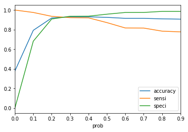

```python
# Let's plot accuracy sensitivity and specificity for various probabilities.
cutoff_df.plot.line(x='prob', y=['accuracy','sensi','speci'])
plt.show()
```

- **As visible from the graph the threshold can be 0.3**

#### ROC Curve

```python
def draw_roc( actual, probs ):
    fpr, tpr, thresholds = metrics.roc_curve( actual, probs,
                                              drop_intermediate = False )
    auc_score = metrics.roc_auc_score( actual, probs )
    plt.figure(figsize=(5, 5))
    plt.plot( fpr, tpr, label='ROC curve (area = %0.2f)' % auc_score )
    plt.plot([0, 1], [0, 1], 'k--')
    plt.xlim([0.0, 1.0])
    plt.ylim([0.0, 1.05])
    plt.xlabel('False Positive Rate or [1 - True Negative Rate]')
    plt.ylabel('True Positive Rate')
    plt.title('Receiver operating characteristic example')
    plt.legend(loc="lower right")
    plt.show()

    return None
```

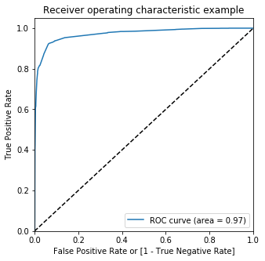

```python
draw_roc(y_train, pred['Prob'])
```

```python
# Final prediction on train and its metrices
y_pred_train_final = pred[0.3]
print(metrics.accuracy_score(y_train, pred[0.3]))
print(metrics.confusion_matrix(y_train, pred[0.3]))
print(metrics.classification_report(y_train, pred[0.3]))
```

```
0.9313073757518202
[[3679  249]
 [ 185 2205]]
              precision    recall  f1-score   support

           0       0.95      0.94      0.94      3928
           1       0.90      0.92      0.91      2390

   micro avg       0.93      0.93      0.93      6318
   macro avg       0.93      0.93      0.93      6318
weighted avg       0.93      0.93      0.93      6318
```

### Predictions on the test and checking the metrices

```python
# Final Prediction on test
y_pred_test_final = model.predict(X_test_sm[X_train_sm.columns]).map(lambda x: 1 if x>0.3 else 0)
```

```python
# Accuracy, confusion matrix, sensitivity, specificity, classification report
print('Accuracy :',metrics.accuracy_score(y_test, y_pred_test_final))
print('Confusion Matrix :\n',metrics.confusion_matrix(y_test, y_pred_test_final))
print('Classification Report :\n',metrics.classification_report(y_test, y_pred_test_final))
```

```
Accuracy : 0.9376153562200074
Confusion Matrix :
 [[1591   93]
 [  76  949]]
Classification Report :
               precision    recall  f1-score   support

           0       0.95      0.94      0.95      1684
           1       0.91      0.93      0.92      1025

   micro avg       0.94      0.94      0.94      2709
   macro avg       0.93      0.94      0.93      2709
weighted avg       0.94      0.94      0.94      2709
```

```python
print('Accuracy :', round((1591+949)/(1591+949+93+76),2))
print('Specificity :',round(1591/(1591+93),2))
print('Sensitivity :',round(949/(949+76),2))
```

```
Accuracy : 0.94
Specificity : 0.94
Sensitivity : 0.93
```

- Model is performing quite good as the **Accuracy, Specificity, Sensitivity, Precision, Recall and f1-score** are all *similar*

### Most important features are

-- Below are the dummies:

- Tags_Lost to EINS
- Tags_Closed by Horizzon
- Tags_Will revert after reading the email